# Explorartory Analysis - Within sessions

Akira Banerjee

2023-09-26

```r
#### Load libraries ####

library (kableExtra)
library (tidyverse)
library (lubridate)
library (YRmisc)
library (gridExtra)
library (ggplot2)
library (arrow)
library (readr)
library (afex)
library (dplyr)
library (knitr)
library (ggpubr)
```

[figure not shown]

```r
#load user defined custom T-test function for analyses
source(here("code/EDA/Within_session/function/TES.R"))

# check if figure folder exists, if not, create a new one
if(!dir.exists(here("code/EDA/Within_session/figure"))){
  dir.create(here("code/EDA/Within_session/figure"))
}


# set the theme for all ggplot2 figures
theme_set(theme_bw() +
            theme(legend.position = "top",
                  legend.direction = "horizontal"))

# use colorblind friendly colors
color_values <- c("#FFC107", "#1E88E5")
color_values_streaks <- c("red", "dark green")
# size of the shapes in the figures
shape_size <- 2.5

# dodge width
dodge_width <- 0.35
```

# Within-session loss-chasing

Losses can be chased within a gambling session. In this set of analyses we assess within-session loss-chasing via - 1.) persistence which refers to continuation of gambling in the face of losses, 2.)increasing stake amount following losses and 3.) increasing speed of play (i.e., post loss speeding) following losses.

```r
# load data
descriptives_df <- read_csv(here("data", "processed_data","EDA", "Within_session", "descriptives_df.csv"))
```

# Player characteristics

Before investigating within-session chasing we first check the 1.) number of players across involvement levels, 2.) number of males and females per involvement level, 3.) average age per gender per involvement level. In other words we account for the basic player characterisits and play behaviour in the exploratory dataset.

```r
### number of players per involvement level

involvement_level <- descriptives_df %>%
  count(group_levels)

### number of males and females per involvement level

gender_inv_level <- descriptives_df %>%
  group_by(group_levels) %>%
  count (gender)%>%
  ungroup()

### average age per gender and involvement level
age_inv_level <- descriptives_df %>%
  group_by(group_levels, gender) %>%
  summarise(mean_age = mean(age),
            sd_age = sd(age))%>%
  ungroup()

table_descriptives <- full_join(age_inv_level, gender_inv_level) #improve the table
colnames(table_descriptives) <- c("Involvement level", "Gender",
                                  "Mean age", "SD age", "N")
table_final <- rempsyc::nice_table(table_descriptives,
           title = c("Table 1", "Descriptive of players"),
           highlight = TRUE)

#save the table
flextable::save_as_docx(table_final, path = "table_final.docx")
```

### Player Age

```r
#### Create dataframe for age pyramid plotting ####
#check the range of age the
min_age <- min(descriptives_df$age) #minimum age
max_age <- max(descriptives_df$age) #maximum age

#### High-involvement ####
high_inv <- descriptives_df%>%
  filter(group_levels == "High-involvement")
high_inv_female <- high_inv%>%
  filter(gender == "Female")
high_inv_male <- high_inv%>%
  filter(gender == "Male")

#create age_group - high involvement
age_group_high_fem <- data.frame(x = table(cut(high_inv_female$age, seq(20,90,5))), gender = "Female", group_level = "High-involvement")

age_group_high_male <- data.frame(x = table(cut(high_inv_male$age, seq(20,90,5))), gender = "Male", group_level = "High-involvement")

age_group_high <- data.frame(rbind(age_group_high_fem,
             age_group_high_male))

#rm(high_inv, high_inv_female, high_inv_male, age_group_high_fem, age_group_high_male) #free R's memory


#### Low-involvement ####
low_inv <- descriptives_df%>%
  filter(group_levels == "Low-involvement")
low_inv_female <- low_inv%>%
  filter(gender == "Female")
low_inv_male <- low_inv%>%
  filter(gender == "Male")


#create age_group - low involvement
age_group_low_fem <- data.frame(x = table(cut(low_inv_female$age, seq(20,90,5))), gender = "Female", group_level = "Low-involvement")

age_group_low_male <- data.frame(x = table(cut(low_inv_male$age, seq(20,90,5))), gender = "Male", group_level = "Low-involvement")

age_group_low <- data.frame(rbind(age_group_low_fem,
                                  age_group_low_male))

# Final Age pyramid dataframe
age_group <- data.frame(rbind(age_group_high,
                              age_group_low))
colnames(age_group) <- c("age_range", "age_count",
                                  "gender", "group")
```

#### Age Pyramid

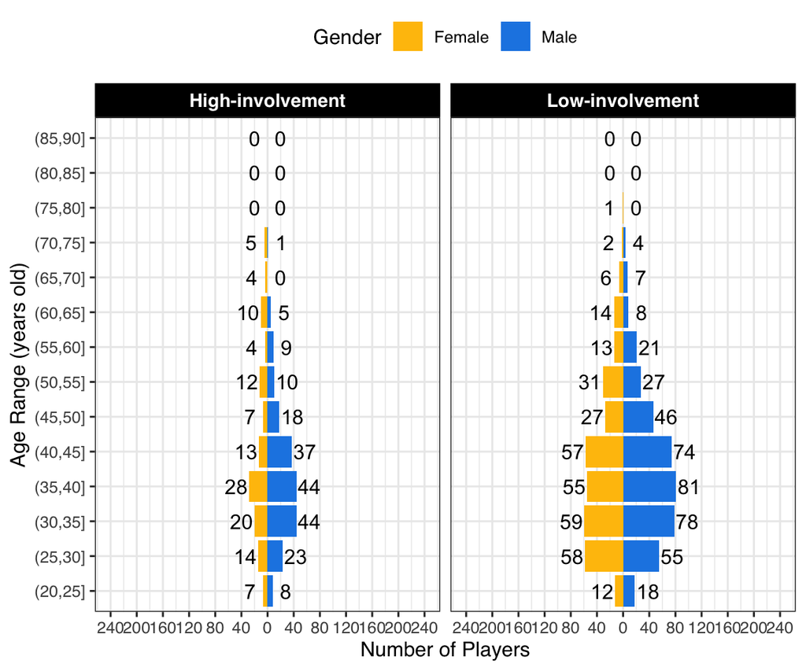

```r
age_pyramids <- ggplot(age_group, aes(age_range, age_count, fill=gender)) +
  # plot bars for males
  geom_col(data=filter(age_group, gender =="Male")) +
  # add the counts next to the bars
  geom_text(data=filter(age_group, gender =="Male"), aes(x=age_range, y = age_count, label = age_count), nudge_y = 20) +
  # plot bars for females, but flip it to the other side
  geom_col(data=filter(age_group, gender=="Female"), aes(y = age_count*(-1))) +
  # add the counts next to the bars
  geom_text(data=filter(age_group, gender =="Female"), aes(x=age_range, y = age_count*(-1), label = age_count), nudge_y = -20) +
  # for high-risk and low-risk group separately
  facet_wrap(~group) +
  # use colorblind-friendly color
  scale_fill_manual(values = color_values) +
  scale_color_manual(values = color_values) +
  labs(x = "Age Range (years old)", y = "Number of Players", fill = "Gender") +
  theme(legend.position = "top", legend.direction = "horizontal") +
  # adjust the tick labels on the y axis
  scale_y_continuous(limits = c(-240, 240), breaks=seq(-240,240,40), labels=abs(seq(-240,240,40))) +
  # flip the x and y axis
  coord_flip() +
    theme(
      strip.text.x = element_text(
        size = 10, color = "white", face = "bold"
        ),
      strip.text.y = element_text(
        size = 10, color = "black", face = "bold.italic"
        )
      ) +
  theme(
   strip.background = element_rect(
     color="black", fill= "black", size=1, linetype="solid"
     )
   ) +
  theme(text = element_text(family = "sans"))

age_pyramids
```

```r
# save the figure in the fig folder
ggsave("figure/age_pyramids.png", age_pyramids)
```

## Number of Rounds

```r
num_rounds <- descriptives_df %>%
  # divide the total number of rounds into bins
  # note that the scale is transformed so that larger values are compressed
  mutate(n_round_bin = cut(n_rounds,
                             breaks = c(0:10, (2:10)*10, (2:10)*100, (2:5)*1000) * 100),
         n_round_label = cut(n_rounds,
                             breaks = c(0:10, (2:10)*10, (2:10)*100, (2:5)*1000) * 100,
                             labels = 1:32)
  ) %>%
  # count the number of players with certain numbers of sessions
  count(group_levels, n_round_bin, n_round_label) %>%
  mutate(
    group = factor(group_levels,
                   labels = c("High-Involvement", "Low-Involvement")),
    n_round_label = as.numeric(n_round_label)
  )
```

Plot the histogram of the players

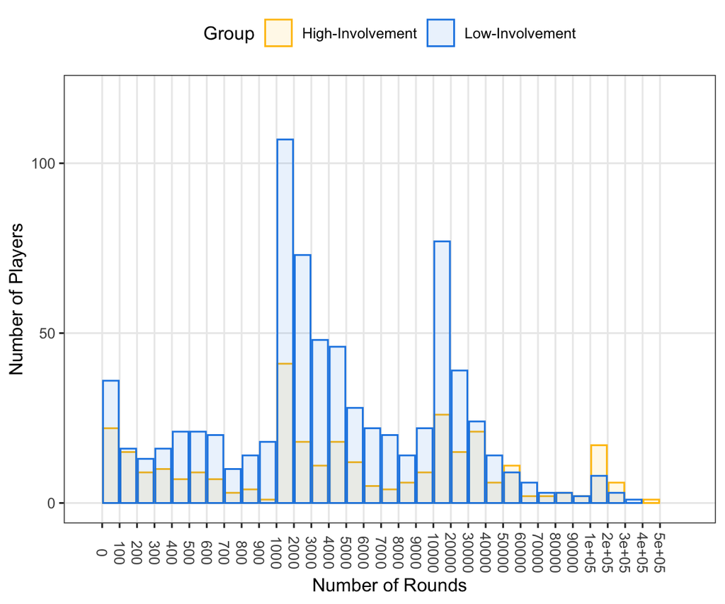

```r
# make a histogram for the total number of sessions
round_hist <- num_rounds %>%
  ggplot(aes(n_round_label, n, fill = group, color = group)) +
  geom_bar(stat = "identity", alpha = 0.1, position = "identity") +
  scale_x_continuous(breaks = 0:32 + 0.5, # note that +0.5 to move the bars horizontally
                     labels = c(0:10, (2:10)*10, (2:10)*100, (2:5)*1000) * 100,
                     limits = c(0, 34)) +
  scale_y_continuous(breaks = (0:9) * 50,
                     labels = (0:9) * 50,
                     limits = c(0, 120)) +
  labs(x = "Number of Rounds", y = "Number of Players", fill = "Group", color = "Group") +
  # use colorblind-friendly color
  scale_fill_manual(values = color_values) +
  scale_color_manual(values = color_values) +
  theme(legend.position = "top", legend.direction = "horizontal",
        panel.grid.minor = element_blank(),
        axis.text.x=element_text(angle = -90, vjust = 0.5))

round_hist
```

```r
# save the figure in the fig folder
ggsave("figure/total_sessions.png", round_hist)
```

```r
# calculate the total numbers of sessions across all players
n_round_total <- sum(descriptives_df$n_rounds)

n_grp_levels <- descriptives_df %>%
  group_by(group_levels)%>%
  count(n_rounds)%>%
  summarise(total_round_num = sum(n_rounds))%>%
  ungroup()

# filter high-involvement players
n_round_HR <- descriptives_df%>%
  filter(group_levels == "High-involvement")

# filter low-involvement players
n_round_LR <- descriptives_df%>%
  filter(group_levels == "Low-involvement")

round_comp <- TES(n_round_HR$n_rounds, n_round_LR$n_rounds, paired = FALSE, conf = 0.95)

round_mean_comp   <- TES(n_round_HR$mean_n_rounds, n_round_LR$mean_n_rounds, paired = FALSE, conf = 0.95)
round_median_comp <- TES(n_round_HR$median_n_rounds, n_round_LR$median_n_rounds, paired = FALSE, conf = 0.95)

# combine and format the results
num_round_comp <- rbind(round_comp, round_mean_comp, round_median_comp) %>%
  mutate(comp = c("Round number", "Mean Round number", "Median Round number")) %>%
  select(comp, everything())

comp_formatted <- num_round_comp %>%
  mutate(
    across(c(mean_x, sd_x, mean_y, sd_y, diff, lowerCI, upperCI), ~round(.x)),
    across(c(df, t, logBF), ~round(.x, digits = 1)),
    across(c(d, g), ~round(.x, digits = 3)))

# show the table
#kable(comp_formatted, caption = "Comparing numbers of rounds between the two groups",
 #     booktabs = T, align = "c") %>%
 # scroll_box(width = "100%", height = "100%")
```

### Round Stakes

```r
# compare the high-risk and the low-risk group
round_stakes_HR <- filter(descriptives_df, group_levels == "High-involvement")
round_stakes_LR <- filter(descriptives_df, group_levels == "Low-involvement")

round_stakes_max_comp    <- TES(round_stakes_HR$stake_max, round_stakes_LR$stake_max, paired = FALSE, conf = 0.95)
round_stakes_min_comp    <- TES(round_stakes_HR$stake_min, round_stakes_LR$stake_min, paired = FALSE, conf = 0.95)
round_stakes_mean_comp   <- TES(round_stakes_HR$stake_mean, round_stakes_LR$stake_mean, paired = FALSE, conf = 0.95)
round_stakes_median_comp <- TES(round_stakes_HR$stake_median, round_stakes_LR$stake_median, paired = FALSE, conf = 0.95)

stake_comp <- rbind(round_stakes_max_comp, round_stakes_min_comp, round_stakes_mean_comp, round_stakes_median_comp) %>%
  mutate(comp = c("Maximum stake", "Minimum stake", "Mean stake", "Median stake")) %>%
  select(comp, everything())

comp_formatted <- stake_comp %>%
  mutate(
    across(c(mean_x, sd_x, mean_y, sd_y, diff, lowerCI, upperCI), ~round(.x, digits = 2)),
    across(c(df, t, logBF), ~round(.x, digits = 3)),
    across(c(d, g), ~round(.x, digits = 3)))

# make a table
#kable(comp_formatted, caption = "Comparing the maximum, minimum, mean and median stake size between two groups",
#      booktabs = T, align = "c") %>%
#  scroll_box(width = "100%", height = "100%")
```

### Round Wins

```r
# compare the high-risk group and the low-risk group
wins_HR <- filter(descriptives_df, group_levels == "High-involvement")
# remove the missing values
wins_HR <- na.omit(wins_HR)

wins_LR <- filter(descriptives_df, group_levels == "Low-involvement")
# remove the missing values
wins_LR <- na.omit(wins_LR)

win_prob_comp   <- TES(wins_HR$win_prob, wins_LR$win_prob, paired = FALSE, conf = .95)

win_max_comp    <- TES(wins_HR$win_max, wins_LR$win_max, paired = FALSE, conf = .95)
win_min_comp    <- TES(wins_HR$win_min, wins_LR$win_min, paired = FALSE, conf = .95)
win_mean_comp   <- TES(wins_HR$win_mean, wins_LR$win_mean, paired = FALSE, conf = .95)
win_median_comp <- TES(wins_HR$win_median, wins_LR$win_median, paired = FALSE, conf = .95)

win_prob_comp <- win_prob_comp %>%
  mutate(comp = "Win probability") %>%
  select(comp, everything())

win_max_comp <- win_max_comp %>%
  mutate(comp = "Maximum win") %>%
  select(comp, everything())

win_min_comp <- win_min_comp %>%
  mutate(comp = "Minimum win") %>%
  select(comp, everything())

win_mean_comp <- win_mean_comp %>%
  mutate(comp = "Mean win") %>%
  select(comp, everything())

win_median_comp <- win_median_comp %>%
  mutate(comp = "Median win") %>%
  select(comp, everything())

win_comp <- rbind(win_prob_comp, win_max_comp, win_min_comp, win_mean_comp, win_median_comp)

comp_formatted <- win_comp %>%
  mutate(
    across(c(mean_x, sd_x, mean_y, sd_y, diff, lowerCI, upperCI), ~round(.x, digits = 2)),
    across(c(df, t, logBF), ~round(.x, digits = 3)),
    across(c(d, g), ~round(.x, digits = 3)))

# make a table
#kable(comp_formatted, caption = "Comparing the probability and amount of wins between two groups.",
#      booktabs = T, align = "c") %>%
 # scroll_box(width = "100%", height = "100%")
```

### Round Losses

```r
# compare the High-involvement group and the Low-involvement group
losses_HR <- filter(descriptives_df, group_levels == "High-involvement")
losses_LR <- filter(descriptives_df, group_levels == "Low-involvement")

loss_prob_comp   <- TES(losses_HR$loss_prob, losses_LR$loss_prob, paired = FALSE, conf = .95)

loss_max_comp    <- TES(losses_HR$loss_max, losses_LR$loss_max, paired = FALSE, conf = .95)
loss_min_comp    <- TES(losses_HR$loss_min, losses_LR$loss_min, paired = FALSE, conf = .95)
loss_mean_comp    <- TES(losses_HR$loss_mean, losses_LR$loss_mean, paired = FALSE, conf = .95)
loss_median_comp    <- TES(losses_HR$loss_median, losses_LR$loss_median, paired = FALSE, conf = .95)

loss_prob_comp <- loss_prob_comp %>%
  mutate(comp = "Loss probability") %>%
  select(comp, everything())

loss_max_comp <- loss_max_comp %>%
  mutate(comp = "Maximum loss") %>%
  select(comp, everything())

loss_min_comp <- loss_min_comp %>%
  mutate(comp = "Minimum loss") %>%
  select(comp, everything())

loss_mean_comp <- loss_mean_comp %>%
  mutate(comp = "Mean loss") %>%
  select(comp, everything())

loss_median_comp <- loss_median_comp %>%
  mutate(comp = "Median loss") %>%
  select(comp, everything())

loss_comp <- rbind(loss_prob_comp, loss_max_comp, loss_min_comp, loss_mean_comp, loss_median_comp)

comp_formatted <- loss_comp %>%
  mutate(
    across(c(mean_x, sd_x, mean_y, sd_y, diff, lowerCI, upperCI), ~round(.x, digits = 2)),
    across(c(df, t, logBF), ~round(.x, digits = 1)),
    across(c(d, g), ~round(.x, digits = 3)))

# make a table
#kable(comp_formatted, caption = "Comparing the amount of losses between two groups.",
   #   booktabs = T, align = "c") %>%
 # scroll_box(width = "100%", height = "100%")
```

### Total spent

```r
# compare the high-risk group and the low-risk group
total_spent_HR <- filter(descriptives_df, group_levels == "High-involvement")
total_spent_LR <- filter(descriptives_df, group_levels == "Low-involvement")

total_spent_comp    <- TES(total_spent_HR$total_spent, total_spent_LR$total_spent, paired = FALSE, conf = .95)

total_spent_comp <- total_spent_comp %>%
  mutate(comp = "Total spent") %>%
  select(comp, everything())

comp_formatted <- total_spent_comp %>%
  mutate(
    across(c(mean_x, sd_x, mean_y, sd_y, diff, lowerCI, upperCI), ~round(.x, digits = 2)),
    across(c(df, t, logBF), ~round(.x, digits = 1)),
    across(c(d, g), ~round(.x, digits = 3)))

# make a table
#kable(comp_formatted, caption = "Comparing the total amount of money spent between two groups.",
      #booktabs = T, align = "c") %>%
  #scroll_box(width = "100%", height = "100%")
```

### Combine in one table

```r
# in the manuscript, we present all information in one table
# here we combine the separate tables into one
one_table <- rbind(num_round_comp, stake_comp, win_comp, loss_comp, total_spent_comp)

# for brevity, we do not report results on maximum and minimum
one_table <- one_table %>%
  filter(!comp %in% c("Maximum stake", "Minimum stake", "Maximum win",
                      "Minimum win", "Maximum loss", "Minimum loss"))

# correct the p values for multiple comparisons
one_table$p <- p.adjust(one_table$pt, method = "holm")

# format the table
one_table <- one_table %>%
  mutate(
    # rename comp into Parameter
    Parameter = comp,
    # for these variables, keep 1 digit after the decimal point
    across(c(mean_x:t, logBF), ~round(.x, digits = 1)),
    # for effect size g, keep 3 digits after the decimal point
    g = round(g, digits = 3),
    # report p values below .001 as < .001
    p = ifelse(p < .001, "<.001", sprintf("%.3f", round(p, digits = 3))),
    # combine mean and standard deviation for each group
    `High-involvement` = paste0(mean_x, " (", sd_x, ")"),
    `Low-involvement` = paste0(mean_y, " (", sd_y, ")")
    ) %>%
  # delete some redundant variables
  select(-c(comp:sd_y), -pt, -pw, -d, -BF) %>%
  select(Parameter, `High-involvement`, `Low-involvement`, diff, lowerCI, upperCI, df, t, p, logBF, g)

# produce the APA tables for publication
table_final_play_beh <- rempsyc::nice_table(one_table ,
           title = c("Table 2", "Comparison of play behaviour across high and low involvement group"))

#save the table
flextable::save_as_docx(table_final_play_beh, path = "table_final_play_beh.docx")

# show the table
kable(one_table, caption = "Comparing characteristics of play behavior at round level between the two groups.",
      booktabs = T, align = "c") %>%
  scroll_box(width = "100%", height = "100%")
```

Comparing characteristics of play behavior at round level between the two groups.

| Parameter | High-involvement | Low-involvement | diff | lowerCI | upperCI | df | t | p | logBF | g |
| --- | --- | --- | --- | --- | --- | --- | --- | --- | --- | --- |
| Round number | 24239.8 (52111.7) | 11626.2 (26537.9) | 12613.5 | 6604.7 | 18622.4 | 395.4 | 4.1 | <.001 | 10.8 | 0.274 |
| Mean Round number | 92.7 (73) | 90.9 (77.9) | 1.8 | -7.9 | 11.6 | 647.4 | 0.4 | 1.000 | -2.5 | 0.024 |
| Median Round number | 59.2 (45.5) | 61.3 (54) | -2.1 | -8.4 | 4.2 | 716.7 | -0.7 | 1.000 | -2.4 | 0.044 |
| Mean stake | 2.1 (2.8) | 1.5 (1.9) | 0.7 | 0.3 | 1.0 | 460.5 | 3.9 | 0.001 | 7.3 | 0.261 |
| Median stake | 1.7 (2.8) | 1.2 (1.9) | 0.6 | 0.2 | 0.9 | 452.5 | 3.4 | 0.007 | 4.8 | 0.223 |
| Win probability | 22.1 (2.6) | 22.3 (2.4) | -0.2 | -0.6 | 0.1 | 557.1 | -1.4 | 0.654 | -1.6 | 0.093 |
| Mean win | 6.5 (9.1) | 4.5 (6.9) | 2.0 | 0.9 | 3.1 | 482.4 | 3.5 | 0.004 | 5.0 | 0.236 |
| Median win | 2.7 (4.5) | 1.8 (2.4) | 0.9 | 0.3 | 1.4 | 399.5 | 3.2 | 0.009 | 5.3 | 0.214 |
| Loss probability | 78.1 (3.4) | 77.8 (2.8) | 0.4 | -0.1 | 0.8 | 518.6 | 1.7 | 0.481 | -1.0 | 0.111 |
| Mean loss | 2.1 (2.8) | 1.5 (1.9) | 0.7 | 0.3 | 1.0 | 460.2 | 3.9 | 0.001 | 7.4 | 0.261 |
| Median loss | 1.7 (2.8) | 1.2 (1.9) | 0.6 | 0.2 | 0.9 | 452.4 | 3.3 | 0.007 | 4.7 | 0.220 |
| Total spent | 1243.3 (8309.4) | 865.6 (3050.3) | 377.6 | -557.5 | 1312.8 | 359.7 | 0.8 | 1.000 | -2.0 | 0.053 |

# Persistance - Probability to quit

Players can chase losses (or wins) by persisting in the face of losses. This is commonly referred to as persistence or continuation in the loss-chasing literature. In this study we operationalize persistence/continuation as the probability of quitting following losses or wins incurred in the previous round. We assess this across outcome streaks and in doing so assess the following research question:Do players chase losses high- (low) players have a higher (lower) probability to quit following losses (wins) across the varying streak lengths of 1, 2 or >2 losses (wins)?

```r
quit_df <- read_csv(here("data", "processed_data","EDA", "Within_session", "quit_df.csv"))
```

# Quit prob basic info

Here we check the total number of players across the involvement levels, the total number of rounds, the mean, SD, minimum and maximum number of rounds in the quit probability dataset.

```r
# number of players in the stakes df
n_players <- quit_df %>%
  group_by(group_levels) %>%
  distinct(player_id) %>%
  count()

#info about number of rounds

n_round <- quit_df %>%
  group_by(group_levels) %>%
  summarise(total_rounds = sum(total_count),
            mean_rounds = mean(total_count),
            sd_rounds = sd(total_count),
            min_rounds = min(total_count),
            max_rounds = max(total_count))
```

# Relative Likelihood of Quitting

```r
# calculate the relative likelihood of quitting
quit_df <-quit_df %>%
  mutate(quit_prob_relative = quit_prob_outcome/quit_prob_overall)
```

### Mixed ANOVA Model: Relative P(Quit)

```r
quit_anova <- aov_ez(id = "player_id",
                        dv = "quit_prob_relative",
                        between = "group_levels",
                        within = c("curr_streak_len","outcome"),
                        data = quit_df,
                        na.rm = TRUE)
quit_anova_table <- nice(quit_anova)

# format the anova table
quit_anova_table <- quit_anova_table%>%
  mutate(
    Parameter = "Relative likelihood to quit (%)",
    Effect = c("Involvement level", "Streak Length","Interaction: Involvement level * Streak length",
               "Outcome", "Interaction: Involvement level * Outcome",
               "Interaction: Streak length * Outcome" ,
               "Interaction: Involvement level * Streak length * Outcome"),
    # remove asterisks from the F values
    `F` = str_remove_all(`F`, "[*]"),
    # remove white space
    `F` = str_trim(`F`),
    p = `p.value`
  ) %>%
  #select(Parameter, Effect, df, MSE, `F`, ges, p)
  select(Effect, df, MSE, `F`, ges, p)

quit_anova_table  %>%
  kable() %>%
  kable_styling() %>%
  scroll_box(width = "100%", height = "400px")
```

| Effect | df | MSE | F | ges | p |
| --- | --- | --- | --- | --- | --- |
| Involvement level | 1, 1004 | 0.12 | 1.67 | <.001 | .196 |
| Streak Length | 1.82, 1823.88 | 0.18 | 1557.39 | .353 | <.001 |
| Interaction: Involvement level * Streak length | 1.82, 1823.88 | 0.18 | 0.06 | <.001 | .927 |
| Outcome | 1, 1004 | 0.18 | 3958.50 | .429 | <.001 |
| Interaction: Involvement level * Outcome | 1, 1004 | 0.18 | 1.95 | <.001 | .163 |
| Interaction: Streak length * Outcome | 1.73, 1739.81 | 0.18 | 2044.96 | .399 | <.001 |
| Interaction: Involvement level * Streak length * Outcome | 1.73, 1739.81 | 0.18 | 0.07 | <.001 | .911 |

```r
#write_csv(quit_anova_table, file = here("data/processed_data/EDA/Within_session/quit_anova_table.csv"))
```

### Plot - Relative P(Quit)

```r
quit_prob_summary <- quit_df %>%
  # use euro cents instead of euros as the unit
  group_by(group_levels) %>%
  group_modify(~Rmisc::summarySEwithin(.x,
                                       measurevar = "quit_prob_relative",
                                       idvar = "player_id",
                                       withinvars = c("outcome", "curr_streak_len"))) %>%
  mutate(
    curr_streak_len = factor(curr_streak_len, levels = c("1", "2", ">2"),
                   labels = c("1", "2", ">2"))
  )%>%
  ungroup()
```

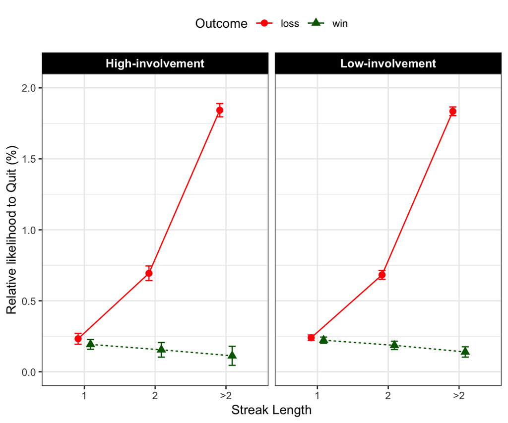

```r
quit_plot <- quit_prob_summary %>%
  group_by(group_levels)%>%
  ggplot(aes(curr_streak_len, quit_prob_relative,
              color = outcome, shape = outcome)) +
  geom_point(position = position_dodge(width = dodge_width), size = shape_size) +
  geom_line(aes(group = outcome, linetype = outcome),
            position = position_dodge(width = dodge_width)) +
  geom_errorbar(aes(ymin = quit_prob_relative-ci, ymax = quit_prob_relative+ci), width = 0.2,
                position = position_dodge(width = dodge_width)) +
  # use colorblind-friendly color
  scale_color_manual(values=color_values_streaks) +
  scale_x_discrete(labels=c("1" = "1", "2" = "2", ">2" = ">2"))+
  ylim(0, 2) +
  labs(x = "Streak Length",
       y = "Relative likelihood to Quit (%)")+
  theme(legend.position = "top", legend.direction = "horizontal") +
  facet_wrap(~group_levels) +
  labs(color = "Outcome",
       shape = "Outcome",
       linetype = "Outcome")+
    theme(
      strip.text.x = element_text(
        size = 10, color = "white", face = "bold"
        ),
      strip.text.y = element_text(
        size = 10, color = "black", face = "bold.italic"
        )
      ) +
  theme(
   strip.background = element_rect(
     color="black", fill="black", size=1, linetype="solid"
     )
   )


quit_plot
```

```r
ggsave("figure/quit_plot.png", quit_plot, width = 6, height = 3)
```

### Pairwise comparison: Relative P(Quit)

Paired t-test: * High-loss vs. High-win_ streak_len_1 * High-loss vs. High-win_ streak_len_2 * High-loss vs. High-win_ streak_len_grt_2 * Low-loss vs. Low-win_ streak_len_1 * Low-loss vs. Low-win_ streak_len_2 * Low-loss vs. Low-win_ streak_len_grt_2

Independent t-test: In the independent group comparison we will compare the two groups - high- and low-involvement groups across each prior outcome and streak lengths and the difference of differences as well.

- High-loss vs. Low-loss_ streak_len_1
- High-loss vs. Low-loss_ streak_len_2
- High-loss vs. Low-loss_ streak_len_grt_2
- High-win vs. Low-win_ streak_len_1
- High-win vs. Low-win_ streak_len_2
- High-win vs. Low-win_ streak_len_grt_2
- (High-Loss - High-Win) vs. (Low-Loss - Low-Win)_streak_len_1
- (High-Loss - High-Win) vs. (Low-Loss - Low-Win)_streak_len_2
- (High-Loss - High-Win) vs. (Low-Loss - Low-Win)_streak_len_grt_2

```r
# Format the table

quit_wide <- quit_df%>%
  pivot_wider(id_cols = c(group_levels, player_id, curr_streak_len),
              names_from = outcome,
              values_from = quit_prob_relative)%>%
  mutate(diff_mean = loss - win)


## PAIRED T-TEST

# within-group comparison

comp_within <- quit_wide %>%
  group_by(group_levels, curr_streak_len)%>%
  group_modify(~TES(.x$loss, .x$win, paired = TRUE))%>%
  mutate(d = dz, g = gav)%>%
  ungroup() %>%
  select(-group_levels, -dz, -gav, -dav)


comp_within_table <- comp_within%>%
  mutate(
    Comparison_group = c("High-Loss vs. High-Win",
                   "High-Loss vs. High-Win",
                   "High-Loss vs. High-Win",
                   "Low-Loss vs. Low-Win",
                   "Low-Loss vs. Low-Win",
                   "Low-Loss vs. Low-Win"),
    Comparison_streak_len = c("1", "2", ">2",
                              "1", "2", ">2")
    ,pt = p.adjust(pt, method = "holm"))

comp_within_table <- comp_within_table%>%
  mutate(
    across(mean_x:upperCI, ~round(.x, digits = 3)),
    across(c(d,g), ~round(.x, digits = 3)),
    t = round(t, digits = 1),
    df = round(df, digits = 1),
    p = ifelse(pt <.001, "<.001", sprintf("%.3f", round(pt, digits = 3))),
    logBF = round(logBF, digits = 2)
  )%>%
  select(Comparison_group, Comparison_streak_len, mean_x:t, p, logBF, g)




## INDEPENDENT T-TEST

#between-group comparison

#Streak_len = 1

#losses
comp_between1_strk_1 <- TES(filter(quit_wide, group_levels == "High-involvement", curr_streak_len == "1")$loss,
                     filter(quit_wide, group_levels == "Low-involvement", curr_streak_len == "1")$loss, paired = FALSE)

#wins
comp_between2_strk_1 <- TES(filter(quit_wide, group_levels == "High-involvement", curr_streak_len == "1")$win,
                     filter(quit_wide, group_levels == "Low-involvement", curr_streak_len == "1")$win, paired = FALSE)

#difference of differences
comp_between3_strk_1 <- TES(filter(quit_wide, group_levels == "High-involvement", curr_streak_len == "1")$diff_mean,
                     filter(quit_wide, group_levels == "Low-involvement", curr_streak_len == "1")$diff_mean, paired = FALSE)

#Streak_len = 2

#losses
comp_between1_strk_2 <- TES(filter(quit_wide, group_levels == "High-involvement", curr_streak_len == "2")$loss,
                     filter(quit_wide, group_levels == "Low-involvement", curr_streak_len == "2")$loss, paired = FALSE)

#wins
comp_between2_strk_2 <- TES(filter(quit_wide, group_levels == "High-involvement", curr_streak_len == "2")$win,
                     filter(quit_wide, group_levels == "Low-involvement", curr_streak_len == "2")$win, paired = FALSE)

#difference of differences
comp_between3_strk_2 <- TES(filter(quit_wide, group_levels == "High-involvement", curr_streak_len == "2")$diff_mean,
                     filter(quit_wide, group_levels == "Low-involvement", curr_streak_len == "2")$diff_mean, paired = FALSE)

#Streak_len = >2

#losses
comp_between1_strk_grt_2 <- TES(filter(quit_wide, group_levels == "High-involvement", curr_streak_len == ">2")$loss,
                     filter(quit_wide, group_levels == "Low-involvement", curr_streak_len == ">2")$loss, paired = FALSE)

#wins
comp_between2_strk_grt_2 <- TES(filter(quit_wide, group_levels == "High-involvement", curr_streak_len == ">2")$win,
                     filter(quit_wide, group_levels == "Low-involvement", curr_streak_len == ">2")$win, paired = FALSE)

#difference of differences
comp_between3_strk_grt_2 <- TES(filter(quit_wide, group_levels == "High-involvement", curr_streak_len == ">2")$diff_mean,
                     filter(quit_wide, group_levels == "Low-involvement", curr_streak_len == ">2")$diff_mean, paired = FALSE)


# Combine all df's from the between-group comparison

comp_between <- bind_rows(comp_between1_strk_1, #high-loss vs. low-loss _ strk_len1
                      comp_between1_strk_2, #high-loss vs. low-loss _ strk_len
                      comp_between1_strk_grt_2, #high-loss vs. low-loss _ strk_len_grt_2
                      comp_between2_strk_1, #high-win vs. low-win _ strk_len1
                      comp_between2_strk_2, #high-win vs. low-win _ strk_len2
                      comp_between2_strk_grt_2, #high-win vs. low-win _ strk_len_grt_2
                      comp_between3_strk_1, #(High-Loss - High-Win) vs. (Low-Loss - Low-Win)_streak_len1
                      comp_between3_strk_2, #(High-Loss - High-Win) vs. (Low-Loss - Low-Win)_streak_len2
                      comp_between3_strk_grt_2) #(High-Loss - High-Win) vs. (Low-Loss - Low-Win)_streak_len_grt_2

comp_between_table <- comp_between %>%
  mutate(
    Comparison_group = c("High-Loss vs. Low-Loss",
                         "High-Loss vs. Low-Loss",
                         "High-Loss vs. Low-Loss",
                         "High-Win vs. Low-Win",
                         "High-Win vs. Low-Win",
                         "High-Win vs. Low-Win",
                         "(High-Loss - High-Win) vs. (Low-Loss - Low-Win)",
                         "(High-Loss - High-Win) vs. (Low-Loss - Low-Win)",
                         "(High-Loss - High-Win) vs. (Low-Loss - Low-Win)"),
    Comparison_streak_len = c("1", "2", ">2",
                              "1", "2", ">2",
                              "1", "2", ">2")
    ,pt = p.adjust(pt, method = "holm"))


comp_between_table <- comp_between_table%>%
  mutate(
    across(mean_x:upperCI, ~round(.x, digits = 2)),
    across(c(d,g), ~round(.x, digits = 3)),
    t = round(t, digits = 1),
    df = round(df, digits = 1),
    p = ifelse(pt <.001, "<.001", sprintf("%.3f", round(pt, digits = 3))),
    logBF = round(logBF, digits = 2)
  )%>%
  select(Comparison_group, Comparison_streak_len, mean_x:t, p, logBF, g)


#create the final df with all the within and between comparisons
final_comp_between_within <- rbind(comp_within_table, comp_between_table)

final_comp_between_within %>%
  kable() %>%
  kable_styling() %>%
  scroll_box(width = "100%", height = "400px")
```

| Comparison_group | Comparison_streak_len | mean_x | sd_x | mean_y | sd_y | diff | lowerCI | upperCI | df | t | p | logBF | g |
| --- | --- | --- | --- | --- | --- | --- | --- | --- | --- | --- | --- | --- | --- |
| High-Loss vs. High-Win | 1 | 0.233 | 0.295 | 0.193 | 0.308 | 0.040 | -0.004 | 0.085 | 291.0 | 1.8 | 0.153 | -1.17 | 0.133 |
| High-Loss vs. High-Win | 2 | 0.694 | 0.427 | 0.155 | 0.454 | 0.539 | 0.466 | 0.612 | 291.0 | 14.6 | <.001 | 76.35 | 1.223 |
| High-Loss vs. High-Win | >2 | 1.843 | 0.270 | 0.113 | 0.638 | 1.730 | 1.645 | 1.816 | 291.0 | 39.9 | <.001 | 267.50 | 3.803 |
| Low-Loss vs. Low-Win | 1 | 0.240 | 0.264 | 0.223 | 0.297 | 0.017 | -0.009 | 0.044 | 713.0 | 1.3 | 0.194 | -2.33 | 0.062 |
| Low-Loss vs. Low-Win | 2 | 0.683 | 0.414 | 0.186 | 0.428 | 0.497 | 0.453 | 0.540 | 713.0 | 22.3 | <.001 | 184.64 | 1.179 |
| Low-Loss vs. Low-Win | >2 | 1.835 | 0.285 | 0.140 | 0.541 | 1.695 | 1.647 | 1.744 | 713.0 | 69.2 | <.001 | 723.21 | 4.105 |
| High-Loss vs. Low-Loss | 1 | 0.230 | 0.300 | 0.240 | 0.260 | -0.010 | -0.050 | 0.030 | 490.7 | -0.4 | 1.000 | -2.49 | 0.025 |
| High-Loss vs. Low-Loss | 2 | 0.690 | 0.430 | 0.680 | 0.410 | 0.010 | -0.050 | 0.070 | 525.6 | 0.4 | 1.000 | -2.48 | 0.026 |
| High-Loss vs. Low-Loss | >2 | 1.840 | 0.270 | 1.840 | 0.280 | 0.010 | -0.030 | 0.050 | 567.0 | 0.4 | 1.000 | -2.48 | 0.028 |
| High-Win vs. Low-Win | 1 | 0.190 | 0.310 | 0.220 | 0.300 | -0.030 | -0.070 | 0.010 | 523.4 | -1.4 | 1.000 | -1.55 | 0.098 |
| High-Win vs. Low-Win | 2 | 0.150 | 0.450 | 0.190 | 0.430 | -0.030 | -0.090 | 0.030 | 513.4 | -1.0 | 1.000 | -2.02 | 0.071 |
| High-Win vs. Low-Win | >2 | 0.110 | 0.640 | 0.140 | 0.540 | -0.030 | -0.110 | 0.060 | 470.5 | -0.6 | 1.000 | -2.32 | 0.045 |
| (High-Loss - High-Win) vs. (Low-Loss - Low-Win) | 1 | 0.040 | 0.390 | 0.020 | 0.360 | 0.020 | -0.030 | 0.070 | 504.6 | 0.9 | 1.000 | -2.16 | 0.060 |
| (High-Loss - High-Win) vs. (Low-Loss - Low-Win) | 2 | 0.540 | 0.630 | 0.500 | 0.600 | 0.040 | -0.040 | 0.130 | 512.6 | 1.0 | 1.000 | -2.05 | 0.069 |
| (High-Loss - High-Win) vs. (Low-Loss - Low-Win) | >2 | 1.730 | 0.740 | 1.700 | 0.660 | 0.030 | -0.060 | 0.130 | 486.6 | 0.7 | 1.000 | -2.29 | 0.049 |

```r
write_csv(final_comp_between_within, file = here("data/processed_data/EDA/Within_session/final_comp_between_within.csv"))
```

```r
#free R's memory

#rm(list=setdiff(ls(), "quit_df"))
```

# Raw Probability to Quit

Here we also report the analyses conducted on the raw P(Quit). Note that in the manuscript the relative P(Quit) analyses with be reported.

### Mixed ANOVA Model: Raw P(Quit)

```r
quit_anova_raw <- aov_ez(id = "player_id",
                        dv = "quit_prob_outcome",
                        between = "group_levels",
                        within = c("curr_streak_len","outcome"),
                        data = quit_df,
                        na.rm = TRUE)
quit_anova_raw_table <- nice(quit_anova_raw)

# format the anova table
quit_anova_raw_table <- quit_anova_raw_table%>%
  mutate(
    Parameter = "Raw probability to quit (%)",
    Effect = c("Involvement level", "Streak Length","Interaction: Involvement level * Streak length",
               "Prior Outcome", "Interaction: Involvement level * Prior Outcome",
               "Interaction: Streak length * Prior Outcome" ,
               "Interaction: Involvement level * Streak length * Prior Outcome"),
    # remove asterisks from the F values
    `F` = str_remove_all(`F`, "[*]"),
    # remove white space
    `F` = str_trim(`F`),
    p = `p.value`
  ) %>%
  #select(Parameter, Effect, df, MSE, `F`, ges, p)
  select(Effect, df, MSE, `F`, ges, p)

quit_anova_raw_table  %>%
  kable() %>%
  kable_styling() %>%
  scroll_box(width = "100%", height = "400px")
```

| Effect | df | MSE | F | ges | p |
| --- | --- | --- | --- | --- | --- |
| Involvement level | 1, 1004 | 11.26 | 2.29 | <.001 | .130 |
| Streak Length | 1.42, 1428.24 | 3.70 | 269.98 | .048 | <.001 |
| Interaction: Involvement level * Streak length | 1.42, 1428.24 | 3.70 | 1.29 | <.001 | .268 |
| Prior Outcome | 1, 1004 | 6.67 | 304.80 | .067 | <.001 |
| Interaction: Involvement level * Prior Outcome | 1, 1004 | 6.67 | 2.00 | <.001 | .158 |
| Interaction: Streak length * Prior Outcome | 1.41, 1416.74 | 3.56 | 325.52 | .055 | <.001 |
| Interaction: Involvement level * Streak length * Prior Outcome | 1.41, 1416.74 | 3.56 | 2.77 + | <.001 | .081 |

### Plot - Raw P(Quit)

```r
quit_prob_raw_summary <- quit_df %>%
  # use euro cents instead of euros as the unit
  group_by(group_levels) %>%
  group_modify(~Rmisc::summarySEwithin(.x,
                                       measurevar = "quit_prob_outcome",
                                       idvar = "player_id",
                                       withinvars = c("outcome", "curr_streak_len"))) %>%
  mutate(
    curr_streak_len = factor(curr_streak_len, levels = c("1", "2", ">2"),
                   labels = c("1", "2", ">2"))
  )%>%
  ungroup()
```

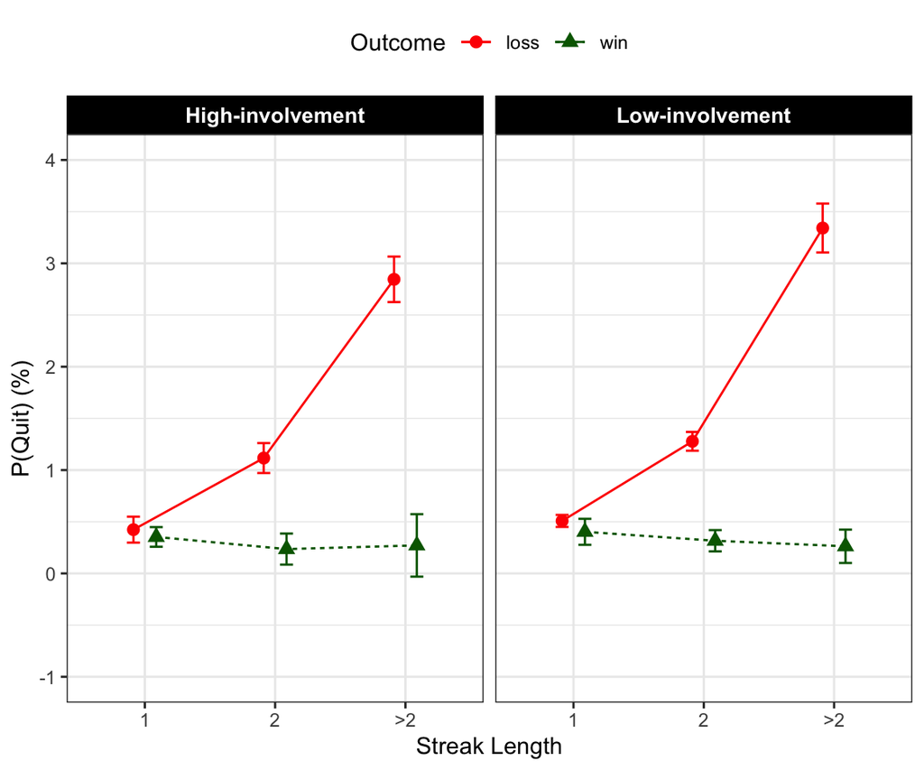

```r
quit_raw_plot <- quit_prob_raw_summary %>%
  group_by(group_levels)%>%
  ggplot(aes(curr_streak_len, quit_prob_outcome,
              color = outcome, shape = outcome)) +
  geom_point(position = position_dodge(width = dodge_width), size = shape_size) +
  geom_line(aes(group = outcome, linetype = outcome),
            position = position_dodge(width = dodge_width)) +
  geom_errorbar(aes(ymin = quit_prob_outcome-ci, ymax = quit_prob_outcome+ci), width = 0.2,
                position = position_dodge(width = dodge_width)) +
  # use colorblind-friendly color
  scale_color_manual(values=color_values_streaks) +
  scale_x_discrete(labels=c("1" = "1", "2" = "2", ">2" = ">2"))+
  ylim(-1,4) +
  labs(x = "Streak Length",
       y = "P(Quit) (%)")+
  theme(legend.position = "top", legend.direction = "horizontal") +
  facet_wrap(~group_levels) +
  labs(color = "Outcome",
       shape = "Outcome",
       linetype = "Outcome")+
    theme(
      strip.text.x = element_text(
        size = 10, color = "white", face = "bold"
        ),
      strip.text.y = element_text(
        size = 10, color = "black", face = "bold.italic"
        )
      ) +
  theme(
   strip.background = element_rect(
     color="black", fill="black", size=1, linetype="solid"
     )
   )


quit_raw_plot
```

```r
ggsave("figure/quit_raw_plot.png", quit_raw_plot, width = 6, height = 3)
```

### Pairwise comparison: Raw P(Quit)

Paired t-test: * High-loss vs. High-win_ streak_len_1 * High-loss vs. High-win_ streak_len_2 * High-loss vs. High-win_ streak_len_grt_2 * Low-loss vs. Low-win_ streak_len_1 * Low-loss vs. Low-win_ streak_len_2 * Low-loss vs. Low-win_ streak_len_grt_2

Independent t-test: In the independent group comparison we will compare the two groups - high- and low-involvement groups across each prior outcome and streak lengths and the difference of differences as well.

- High-loss vs. Low-loss_ streak_len_1
- High-loss vs. Low-loss_ streak_len_2
- High-loss vs. Low-loss_ streak_len_grt_2
- High-win vs. Low-win_ streak_len_1
- High-win vs. Low-win_ streak_len_2
- High-win vs. Low-win_ streak_len_grt_2
- (High-Loss - High-Win) vs. (Low-Loss - Low-Win)_streak_len_1
- (High-Loss - High-Win) vs. (Low-Loss - Low-Win)_streak_len_2
- (High-Loss - High-Win) vs. (Low-Loss - Low-Win)_streak_len_grt_2

```r
# Format the table

quit_wide_raw <- quit_df%>%
  pivot_wider(id_cols = c(group_levels, player_id, curr_streak_len),
              names_from = outcome,
              values_from = quit_prob_outcome)%>%
  mutate(diff_mean = loss - win)


## PAIRED T-TEST

# within-group comparison

comp_within_raw <- quit_wide_raw %>%
  group_by(group_levels, curr_streak_len)%>%
  group_modify(~TES(.x$loss, .x$win, paired = TRUE))%>%
  mutate(d = dz, g = gav)%>%
  ungroup() %>%
  select(-group_levels, -dz, -gav, -dav)


comp_within_table <- comp_within_raw%>%
  mutate(
    Comparison_group = c("High-Loss vs. High-Win",
                   "High-Loss vs. High-Win",
                   "High-Loss vs. High-Win",
                   "Low-Loss vs. Low-Win",
                   "Low-Loss vs. Low-Win",
                   "Low-Loss vs. Low-Win"),
    Comparison_streak_len = c("1", "2", ">2",
                              "1", "2", ">2")
    ,pt = p.adjust(pt, method = "holm"))

comp_within_table <- comp_within_table%>%
  mutate(
    across(mean_x:upperCI, ~round(.x, digits = 3)),
    across(c(d,g), ~round(.x, digits = 3)),
    t = round(t, digits = 1),
    df = round(df, digits = 1),
    p = ifelse(pt <.001, "<.001", sprintf("%.3f", round(pt, digits = 3))),
    logBF = round(logBF, digits = 2)
  )%>%
  select(Comparison_group, Comparison_streak_len, mean_x:t, p, logBF, g)
```

```r
## INDEPENDENT T-TEST

#between-group comparison

#Streak_len = 1

#losses
comp_between1_strk_1 <- TES(filter(quit_wide_raw, group_levels == "High-involvement", curr_streak_len == "1")$loss,
                     filter(quit_wide_raw, group_levels == "Low-involvement", curr_streak_len == "1")$loss, paired = FALSE)

#wins
comp_between2_strk_1 <- TES(filter(quit_wide_raw, group_levels == "High-involvement", curr_streak_len == "1")$win,
                     filter(quit_wide_raw, group_levels == "Low-involvement", curr_streak_len == "1")$win, paired = FALSE)

#difference of differences
comp_between3_strk_1 <- TES(filter(quit_wide_raw, group_levels == "High-involvement", curr_streak_len == "1")$diff_mean,
                     filter(quit_wide_raw, group_levels == "Low-involvement", curr_streak_len == "1")$diff_mean, paired = FALSE)

#Streak_len = 2

#losses
comp_between1_strk_2 <- TES(filter(quit_wide_raw, group_levels == "High-involvement", curr_streak_len == "2")$loss,
                     filter(quit_wide_raw, group_levels == "Low-involvement", curr_streak_len == "2")$loss, paired = FALSE)

#wins
comp_between2_strk_2 <- TES(filter(quit_wide_raw, group_levels == "High-involvement", curr_streak_len == "2")$win,
                     filter(quit_wide_raw, group_levels == "Low-involvement", curr_streak_len == "2")$win, paired = FALSE)

#difference of differences
comp_between3_strk_2 <- TES(filter(quit_wide_raw, group_levels == "High-involvement", curr_streak_len == "2")$diff_mean,
                     filter(quit_wide_raw, group_levels == "Low-involvement", curr_streak_len == "2")$diff_mean, paired = FALSE)

#Streak_len = >2

#losses
comp_between1_strk_grt_2 <- TES(filter(quit_wide_raw, group_levels == "High-involvement", curr_streak_len == ">2")$loss,
                     filter(quit_wide_raw, group_levels == "Low-involvement", curr_streak_len == ">2")$loss, paired = FALSE)

#wins
comp_between2_strk_grt_2 <- TES(filter(quit_wide_raw, group_levels == "High-involvement", curr_streak_len == ">2")$win,
                     filter(quit_wide_raw, group_levels == "Low-involvement", curr_streak_len == ">2")$win, paired = FALSE)

#difference of differences
comp_between3_strk_grt_2 <- TES(filter(quit_wide_raw, group_levels == "High-involvement", curr_streak_len == ">2")$diff_mean,
                     filter(quit_wide_raw, group_levels == "Low-involvement", curr_streak_len == ">2")$diff_mean, paired = FALSE)


# Combine all df's from the between-group comparison

comp_between <- bind_rows(comp_between1_strk_1, #high-loss vs. low-loss _ strk_len1
                      comp_between1_strk_2, #high-loss vs. low-loss _ strk_len
                      comp_between1_strk_grt_2, #high-loss vs. low-loss _ strk_len_grt_2
                      comp_between2_strk_1, #high-win vs. low-win _ strk_len1
                      comp_between2_strk_2, #high-win vs. low-win _ strk_len2
                      comp_between2_strk_grt_2, #high-win vs. low-win _ strk_len_grt_2
                      comp_between3_strk_1, #(High-Loss - High-Win) vs. (Low-Loss - Low-Win)_streak_len1
                      comp_between3_strk_2, #(High-Loss - High-Win) vs. (Low-Loss - Low-Win)_streak_len2
                      comp_between3_strk_grt_2) #(High-Loss - High-Win) vs. (Low-Loss - Low-Win)_streak_len_grt_2

comp_between_table <- comp_between %>%
  mutate(
    Comparison_group = c("High-Loss vs. Low-Loss",
                         "High-Loss vs. Low-Loss",
                         "High-Loss vs. Low-Loss",
                         "High-Win vs. Low-Win",
                         "High-Win vs. Low-Win",
                         "High-Win vs. Low-Win",
                         "(High-Loss - High-Win) vs. (Low-Loss - Low-Win)",
                         "(High-Loss - High-Win) vs. (Low-Loss - Low-Win)",
                         "(High-Loss - High-Win) vs. (Low-Loss - Low-Win)"),
    Comparison_streak_len = c("1", "2", ">2",
                              "1", "2", ">2",
                              "1", "2", ">2")
    ,pt = p.adjust(pt, method = "holm"))


comp_between_table <- comp_between_table%>%
  mutate(
    across(mean_x:upperCI, ~round(.x, digits = 2)),
    across(c(d,g), ~round(.x, digits = 3)),
    t = round(t, digits = 1),
    df = round(df, digits = 1),
    p = ifelse(pt <.001, "<.001", sprintf("%.3f", round(pt, digits = 3))),
    logBF = round(logBF, digits = 2)
  )%>%
  select(Comparison_group, Comparison_streak_len, mean_x:t, p, logBF, g)


#create the final df with all the within and between comparisons
final_comp_between_within <- rbind(comp_within_table, comp_between_table)

final_comp_between_within %>%
  kable() %>%
  kable_styling() %>%
  scroll_box(width = "100%", height = "400px")
```

| Comparison_group | Comparison_streak_len | mean_x | sd_x | mean_y | sd_y | diff | lowerCI | upperCI | df | t | p | logBF | g |
| --- | --- | --- | --- | --- | --- | --- | --- | --- | --- | --- | --- | --- | --- |
| High-Loss vs. High-Win | 1 | 0.424 | 0.914 | 0.353 | 1.037 | 0.070 | -0.078 | 0.218 | 291.0 | 0.9 | 0.350 | -2.29 | 0.072 |
| High-Loss vs. High-Win | 2 | 1.116 | 1.300 | 0.236 | 0.963 | 0.881 | 0.698 | 1.063 | 291.0 | 9.5 | <.001 | 36.25 | 0.777 |
| High-Loss vs. High-Win | >2 | 2.845 | 2.245 | 0.271 | 2.981 | 2.574 | 2.167 | 2.981 | 291.0 | 12.5 | <.001 | 58.95 | 0.984 |
| Low-Loss vs. Low-Win | 1 | 0.508 | 1.527 | 0.403 | 0.933 | 0.105 | -0.019 | 0.229 | 713.0 | 1.7 | 0.191 | -1.78 | 0.086 |
| Low-Loss vs. Low-Win | 2 | 1.278 | 2.235 | 0.316 | 1.184 | 0.962 | 0.816 | 1.108 | 713.0 | 12.9 | <.001 | 71.65 | 0.562 |
| Low-Loss vs. Low-Win | >2 | 3.341 | 4.281 | 0.263 | 2.065 | 3.079 | 2.756 | 3.402 | 713.0 | 18.7 | <.001 | 138.80 | 0.970 |
| High-Loss vs. Low-Loss | 1 | 0.420 | 0.910 | 0.510 | 1.530 | -0.080 | -0.240 | 0.070 | 871.3 | -1.1 | 1.000 | -2.17 | 0.075 |
| High-Loss vs. Low-Loss | 2 | 1.120 | 1.300 | 1.280 | 2.230 | -0.160 | -0.380 | 0.060 | 889.1 | -1.4 | 1.000 | -1.90 | 0.099 |
| High-Loss vs. Low-Loss | >2 | 2.850 | 2.250 | 3.340 | 4.280 | -0.500 | -0.900 | -0.090 | 946.0 | -2.4 | 0.151 | -0.83 | 0.166 |
| High-Win vs. Low-Win | 1 | 0.350 | 1.040 | 0.400 | 0.930 | -0.050 | -0.190 | 0.090 | 493.5 | -0.7 | 1.000 | -2.29 | 0.049 |
| High-Win vs. Low-Win | 2 | 0.240 | 0.960 | 0.320 | 1.180 | -0.080 | -0.220 | 0.060 | 659.4 | -1.1 | 1.000 | -2.03 | 0.078 |
| High-Win vs. Low-Win | >2 | 0.270 | 2.980 | 0.260 | 2.070 | 0.010 | -0.370 | 0.380 | 410.0 | 0.0 | 1.000 | -2.55 | 0.003 |
| (High-Loss - High-Win) vs. (Low-Loss - Low-Win) | 1 | 0.070 | 1.280 | 0.110 | 1.690 | -0.030 | -0.230 | 0.160 | 703.9 | -0.4 | 1.000 | -2.51 | 0.025 |
| (High-Loss - High-Win) vs. (Low-Loss - Low-Win) | 2 | 0.880 | 1.580 | 0.960 | 1.990 | -0.080 | -0.310 | 0.150 | 672.6 | -0.7 | 1.000 | -2.37 | 0.047 |
| (High-Loss - High-Win) vs. (Low-Loss - Low-Win) | >2 | 2.570 | 3.530 | 3.080 | 4.400 | -0.500 | -1.020 | 0.010 | 667.4 | -1.9 | 0.451 | -1.06 | 0.133 |

#Stake Amount change

Players may chase losses by increasing their stake sizes following losses. In this set of analyses we aim to assess if players chase losses by increasing stake amount following incurring sequential losses (wins) of streak lengths 1, 2 and >2 and do we observe systematic differences across high- and low-involvement players?

```r
# load data
stake_change_df <- read_csv(here("data", "processed_data","EDA", "Within_session", "stake_change_df.csv"))
```

## Stake size change overall basic info

Here we check the total number of players across the involvement levels, the total number of rounds, the mean, SD, minimum and maximum number of rounds in the quit probability dataset.

```r
# number of players in the stakes df
n_players <- stake_change_df %>%
  group_by(group_levels) %>%
  distinct(player_id) %>%
  count()

#info about number of rounds

n_round <- stake_change_df %>%
  group_by(group_levels) %>%
  summarise(total_rounds = sum(n_round),
            mean_rounds = mean(n_round),
            sd_rounds = sd(n_round),
            min_rounds = min(n_round),
            max_rounds = max(n_round))
```

Players can chase their losses by increasing stake sizes following losses. In this script we will analyse if players increase their stakes following losses and wins across varying streak lengths of - 1.) 1, 2.) 2 and 3.) >2 streak length. We will run a mixed anova model (2 x 2 x 3 design) in which the between-group factor is group levels (high- and low-involvement) and the within-group factors is a.) previous round outcome and b.) streak length. The dependent variable here is the overall mean stake size change.

## Mixed ANOVA Model - Stake amount change

```r
stake_change_anova <- aov_ez(id = "player_id",
                        dv = "stake_change_size_overall",
                        between = "group_levels",
                        within = c("prev_streak_len","prev_outcome"),
                        data = stake_change_df,
                        na.rm = TRUE)
stake_change_anova_table <- nice(stake_change_anova)

# format the anova table
change_anova_table <- stake_change_anova_table%>%
  mutate(
    Parameter = "Change in stake (euro)",
    Effect = c("Involvement level", "Streak Length","Interaction: Involvement level * Streak length",
               "Prior Outcome", "Interaction: Involvement level * Prior Outcome",
               "Interaction: Streak length * Prior Outcome" ,
               "Interaction: Involvement level * Streak length * Prior Outcome"),
    # remove asterisks from the F values
    `F` = str_remove_all(`F`, "[*]"),
    # remove white space
    `F` = str_trim(`F`),
    p = `p.value`
  ) %>%
  #select(Parameter, Effect, df, MSE, `F`, ges, p)
  select(Effect, df, MSE, `F`, ges, p)

#stake_change_anova_df <- rempsyc::nice_table(stake_change_anova_table,
     #      title = c("Table 3", "Statistical analyses on change in stakes"))

#save the table
#flextable::save_as_docx(stake_change_anova_table, path = "stake_change_anova.docx")


change_anova_table  %>%
  kable() %>%
  kable_styling() %>%
  scroll_box(width = "100%", height = "400px")
```

| Effect | df | MSE | F | ges | p |
| --- | --- | --- | --- | --- | --- |
| Involvement level | 1, 1004 | 0.00 | 0.31 | <.001 | .575 |
| Streak Length | 1.84, 1843.62 | 0.00 | 5.69 | <.001 | .004 |
| Interaction: Involvement level * Streak length | 1.84, 1843.62 | 0.00 | 1.96 | <.001 | .145 |
| Prior Outcome | 1, 1004 | 0.00 | 9.46 | .003 | .002 |
| Interaction: Involvement level * Prior Outcome | 1, 1004 | 0.00 | 2.71 + | <.001 | .100 |
| Interaction: Streak length * Prior Outcome | 1.64, 1651.09 | 0.00 | 6.27 | .002 | .004 |
| Interaction: Involvement level * Streak length * Prior Outcome | 1.64, 1651.09 | 0.00 | 1.01 | <.001 | .350 |

```r
stake_change_summary <- stake_change_df %>%
  # use euro cents instead of euros as the unit
  mutate(stake_change_size_overall = stake_change_size_overall * 100) %>%
  group_by(group_levels) %>%
  group_modify(~Rmisc::summarySEwithin(.x,
                                       measurevar = "stake_change_size_overall",
                                       idvar = "player_id",
                                       withinvars = c("prev_outcome", "prev_streak_len"))) %>%
  mutate(
    prev_streak_len = factor(prev_streak_len, levels = c("1", "2", ">2"),
                   labels = c("1", "2", ">2"))
  )%>%
  ungroup()
```

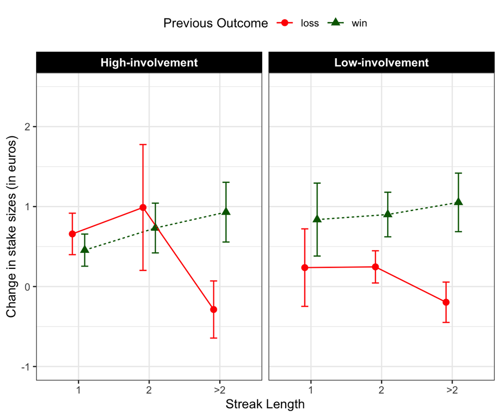

```r
stake_change_plot <- stake_change_summary %>%
  group_by(group_levels)%>%
  ggplot(aes(prev_streak_len, stake_change_size_overall,
              color = prev_outcome, shape = prev_outcome)) +
  geom_point(position = position_dodge(width = dodge_width), size = shape_size) +
  geom_line(aes(group = prev_outcome, linetype = prev_outcome),
            position = position_dodge(width = dodge_width)) +
  geom_errorbar(aes(ymin = stake_change_size_overall-ci, ymax = stake_change_size_overall+ci), width = 0.2,
                position = position_dodge(width = dodge_width)) +
  # use colorblind-friendly color
  scale_color_manual(values=color_values_streaks) +
  scale_x_discrete(labels=c("1" = "1", "2" = "2", ">2" = ">2"))+
  ylim(-1, 2.5) +
  labs(x = "Streak Length",
       y = "Change in stake sizes (in euros)")+
  theme(legend.position = "top", legend.direction = "horizontal") +
  facet_wrap(~group_levels) +
  labs(color = "Previous Outcome",
       shape = "Previous Outcome",
       linetype = "Previous Outcome")+
    theme(
      strip.text.x = element_text(
        size = 10, color = "white", face = "bold"
        ),
      strip.text.y = element_text(
        size = 10, color = "black", face = "bold.italic"
        )
      ) +
  theme(
   strip.background = element_rect(
     color="black", fill="black", size=1, linetype="solid"
     )
   )


stake_change_plot
```

```r
ggsave("figure/stake_change_plot.png", stake_change_plot, width = 6, height = 3)
```

## Pairwise comparison - Stake change overall

Next we will conduct 4 bonferroni-correct post-hoc t-test pairwise comparisons. In the first paired t-tests we will compare the overall mean stake size change across each prior outcome and streak lengths:

Paired t-test: * High-loss vs. High-win_ streak_len_1 * High-loss vs. High-win_ streak_len_2 * High-loss vs. High-win_ streak_len_grt_2 * Low-loss vs. Low-win_ streak_len_1 * Low-loss vs. Low-win_ streak_len_2 * Low-loss vs. Low-win_ streak_len_grt_2

Independent t-test: In the independent group comparison we will compare the two groups - high- and low-involvement groups across each prior outcome and streak lengths and the difference of differences as well.

- High-loss vs. Low-loss_ streak_len_1
- High-loss vs. Low-loss_ streak_len_2
- High-loss vs. Low-loss_ streak_len_grt_2
- High-win vs. Low-win_ streak_len_1
- High-win vs. Low-win_ streak_len_2
- High-win vs. Low-win_ streak_len_grt_2
- (High-Loss - High-Win) vs. (Low-Loss - Low-Win)_streak_len_1
- (High-Loss - High-Win) vs. (Low-Loss - Low-Win)_streak_len_2
- (High-Loss - High-Win) vs. (Low-Loss - Low-Win)_streak_len_grt_2

```r
# Format the table

stake_change_size_overall_wide <- stake_change_df%>%
  pivot_wider(id_cols = c(group_levels, player_id, prev_streak_len),
              names_from = prev_outcome,
              values_from = stake_change_size_overall)%>%
  mutate(diff_mean = loss - win)


## PAIRED T-TEST

# within-group comparison

comp_within <- stake_change_size_overall_wide %>%
  group_by(group_levels, prev_streak_len)%>%
  group_modify(~TES(.x$loss, .x$win, paired = TRUE))%>%
  mutate(d = dz, g = gav)%>%
  ungroup() %>%
  select(-group_levels, -dz, -gav, -dav)


comp_within_table <- comp_within%>%
  mutate(
    Comparison_group = c("High-Loss vs. High-Win",
                   "High-Loss vs. High-Win",
                   "High-Loss vs. High-Win",
                   "Low-Loss vs. Low-Win",
                   "Low-Loss vs. Low-Win",
                   "Low-Loss vs. Low-Win"),
    Comparison_streak_len = c("1", "2", ">2",
                              "1", "2", ">2")
    ,pt = p.adjust(pt, method = "holm"))

comp_within_table <- comp_within_table%>%
  mutate(
    across(mean_x:upperCI, ~round(.x, digits = 3)),
    across(c(d,g), ~round(.x, digits = 3)),
    t = round(t, digits = 1),
    df = round(df, digits = 1),
    p = ifelse(pt <.001, "<.001", sprintf("%.3f", round(pt, digits = 3))),
    logBF = round(logBF, digits = 2)
  )%>%
  select(Comparison_group, Comparison_streak_len, mean_x:t, p, logBF, g)




## INDEPENDENT T-TEST

#between-group comparison

#Streak_len = 1

#losses
comp_between1_strk_1 <- TES(filter(stake_change_size_overall_wide, group_levels == "High-involvement", prev_streak_len == "1")$loss,
                     filter(stake_change_size_overall_wide, group_levels == "Low-involvement", prev_streak_len == "1")$loss, paired = FALSE)

#wins
comp_between2_strk_1 <- TES(filter(stake_change_size_overall_wide, group_levels == "High-involvement", prev_streak_len == "1")$win,
                     filter(stake_change_size_overall_wide, group_levels == "Low-involvement", prev_streak_len == "1")$win, paired = FALSE)

#difference of differences
comp_between3_strk_1 <- TES(filter(stake_change_size_overall_wide, group_levels == "High-involvement", prev_streak_len == "1")$diff_mean,
                     filter(stake_change_size_overall_wide, group_levels == "Low-involvement", prev_streak_len == "1")$diff_mean, paired = FALSE)

#Streak_len = 2

#losses
comp_between1_strk_2 <- TES(filter(stake_change_size_overall_wide, group_levels == "High-involvement", prev_streak_len == "2")$loss,
                     filter(stake_change_size_overall_wide, group_levels == "Low-involvement", prev_streak_len == "2")$loss, paired = FALSE)

#wins
comp_between2_strk_2 <- TES(filter(stake_change_size_overall_wide, group_levels == "High-involvement", prev_streak_len == "2")$win,
                     filter(stake_change_size_overall_wide, group_levels == "Low-involvement", prev_streak_len == "2")$win, paired = FALSE)

#difference of differences
comp_between3_strk_2 <- TES(filter(stake_change_size_overall_wide, group_levels == "High-involvement", prev_streak_len == "2")$diff_mean,
                     filter(stake_change_size_overall_wide, group_levels == "Low-involvement", prev_streak_len == "2")$diff_mean, paired = FALSE)

#Streak_len = >2

#losses
comp_between1_strk_grt_2 <- TES(filter(stake_change_size_overall_wide, group_levels == "High-involvement", prev_streak_len == ">2")$loss,
                     filter(stake_change_size_overall_wide, group_levels == "Low-involvement", prev_streak_len == ">2")$loss, paired = FALSE)

#wins
comp_between2_strk_grt_2 <- TES(filter(stake_change_size_overall_wide, group_levels == "High-involvement", prev_streak_len == ">2")$win,
                     filter(stake_change_size_overall_wide, group_levels == "Low-involvement", prev_streak_len == ">2")$win, paired = FALSE)

#difference of differences
comp_between3_strk_grt_2 <- TES(filter(stake_change_size_overall_wide, group_levels == "High-involvement", prev_streak_len == ">2")$diff_mean,
                     filter(stake_change_size_overall_wide, group_levels == "Low-involvement", prev_streak_len == ">2")$diff_mean, paired = FALSE)


# Combine all df's from the between-group comparison

comp_between <- bind_rows(comp_between1_strk_1, #high-loss vs. low-loss _ strk_len1
                      comp_between1_strk_2, #high-loss vs. low-loss _ strk_len
                      comp_between1_strk_grt_2, #high-loss vs. low-loss _ strk_len_grt_2
                      comp_between2_strk_1, #high-win vs. low-win _ strk_len1
                      comp_between2_strk_2, #high-win vs. low-win _ strk_len2
                      comp_between2_strk_grt_2, #high-win vs. low-win _ strk_len_grt_2
                      comp_between3_strk_1, #(High-Loss - High-Win) vs. (Low-Loss - Low-Win)_streak_len1
                      comp_between3_strk_2, #(High-Loss - High-Win) vs. (Low-Loss - Low-Win)_streak_len2
                      comp_between3_strk_grt_2) #(High-Loss - High-Win) vs. (Low-Loss - Low-Win)_streak_len_grt_2

comp_between_table <- comp_between %>%
  mutate(
    Comparison_group = c("High-Loss vs. Low-Loss",
                         "High-Loss vs. Low-Loss",
                         "High-Loss vs. Low-Loss",
                         "High-Win vs. Low-Win",
                         "High-Win vs. Low-Win",
                         "High-Win vs. Low-Win",
                         "(High-Loss - High-Win) vs. (Low-Loss - Low-Win)",
                         "(High-Loss - High-Win) vs. (Low-Loss - Low-Win)",
                         "(High-Loss - High-Win) vs. (Low-Loss - Low-Win)"),
    Comparison_streak_len = c("1", "2", ">2",
                              "1", "2", ">2",
                              "1", "2", ">2")
    ,pt = p.adjust(pt, method = "holm"))


comp_between_table <- comp_between_table%>%
  mutate(
    across(mean_x:upperCI, ~round(.x, digits = 2)),
    across(c(d,g), ~round(.x, digits = 3)),
    t = round(t, digits = 1),
    df = round(df, digits = 1),
    p = ifelse(pt <.001, "<.001", sprintf("%.3f", round(pt, digits = 3))),
    logBF = round(logBF, digits = 2)
  )%>%
  select(Comparison_group, Comparison_streak_len, mean_x:t, p, logBF, g)


#create the final df with all the within and between comparisons
final_comp_between_within <- rbind(comp_within_table, comp_between_table)
# save the df as a csv
#write_csv(final_comp_between_within, file = here("data/processed_data/EDA/Within_session/final_comp_between_within.csv"))

final_comp_between_within %>%
  kable() %>%
  kable_styling() %>%
  scroll_box(width = "100%", height = "400px")
```

| Comparison_group | Comparison_streak_len | mean_x | sd_x | mean_y | sd_y | diff | lowerCI | upperCI | df | t | p | logBF | g |
| --- | --- | --- | --- | --- | --- | --- | --- | --- | --- | --- | --- | --- | --- |
| High-Loss vs. High-Win | 1 | 0.007 | 0.019 | 0.005 | 0.017 | 0.002 | 0.000 | 0.004 | 291.0 | 1.6 | 0.307 | -1.40 | 0.111 |
| High-Loss vs. High-Win | 2 | 0.010 | 0.077 | 0.007 | 0.025 | 0.003 | -0.007 | 0.012 | 291.0 | 0.5 | 0.590 | -2.58 | 0.051 |
| High-Loss vs. High-Win | >2 | -0.003 | 0.025 | 0.009 | 0.031 | -0.012 | -0.017 | -0.007 | 291.0 | -4.6 | <.001 | 7.54 | 0.433 |
| Low-Loss vs. Low-Win | 1 | 0.002 | 0.058 | 0.008 | 0.060 | -0.006 | -0.014 | 0.002 | 713.0 | -1.4 | 0.316 | -2.18 | 0.102 |
| Low-Loss vs. Low-Win | 2 | 0.002 | 0.022 | 0.009 | 0.045 | -0.007 | -0.010 | -0.003 | 713.0 | -3.3 | 0.004 | 2.31 | 0.195 |
| Low-Loss vs. Low-Win | >2 | -0.002 | 0.024 | 0.011 | 0.058 | -0.012 | -0.018 | -0.007 | 713.0 | -4.8 | <.001 | 8.15 | 0.305 |
| High-Loss vs. Low-Loss | 1 | 0.010 | 0.020 | 0.000 | 0.060 | 0.000 | 0.000 | 0.010 | 974.4 | 1.7 | 0.630 | -1.84 | 0.119 |
| High-Loss vs. Low-Loss | 2 | 0.010 | 0.080 | 0.000 | 0.020 | 0.010 | 0.000 | 0.020 | 311.3 | 1.6 | 0.630 | 0.18 | 0.113 |
| High-Loss vs. Low-Loss | >2 | 0.000 | 0.030 | 0.000 | 0.020 | 0.000 | 0.000 | 0.000 | 505.0 | -0.5 | 1.000 | -2.41 | 0.036 |
| High-Win vs. Low-Win | 1 | 0.000 | 0.020 | 0.010 | 0.060 | 0.000 | -0.010 | 0.000 | 939.6 | -1.6 | 0.630 | -1.99 | 0.108 |
| High-Win vs. Low-Win | 2 | 0.010 | 0.020 | 0.010 | 0.040 | 0.000 | -0.010 | 0.000 | 922.0 | -0.8 | 1.000 | -2.37 | 0.053 |
| High-Win vs. Low-Win | >2 | 0.010 | 0.030 | 0.010 | 0.060 | 0.000 | -0.010 | 0.000 | 942.8 | -0.4 | 1.000 | -2.50 | 0.030 |
| (High-Loss - High-Win) vs. (Low-Loss - Low-Win) | 1 | 0.000 | 0.020 | -0.010 | 0.110 | 0.010 | 0.000 | 0.020 | 824.4 | 1.8 | 0.630 | -1.85 | 0.126 |
| (High-Loss - High-Win) vs. (Low-Loss - Low-Win) | 2 | 0.000 | 0.080 | -0.010 | 0.050 | 0.010 | 0.000 | 0.020 | 393.8 | 1.8 | 0.630 | -0.38 | 0.123 |
| (High-Loss - High-Win) vs. (Low-Loss - Low-Win) | >2 | -0.010 | 0.040 | -0.010 | 0.070 | 0.000 | -0.010 | 0.010 | 819.0 | 0.1 | 1.000 | -2.55 | 0.006 |

# Stake size change probability

In this section we want to assess the probability of changing stake sizes following losses and wins across varying streak lengths of - 1.) 1, 2.) 2 and 3.) >2 streak length across high- and low-involvement groups. We will run a mixed anova model (2 x 2 x 3 design) in which the between-group factor is group levels (high- and low-involvement) and the within-group factors is a.) previous round outcome and b.) streak length. The dependent variable here is the overall mean probability of changing stake sizes.

```r
#free R's memory

#rm(list=setdiff(ls(), "stake_change_df"))
```

## Mixed ANOVA Model: Stake change probability

```r
# ANOVA - stake change proportion
stake_change_prob_anova <-
  aov_ez(id = "player_id"
         , dv = "stake_change_prop"
         , data = stake_change_df
         , between = "group_levels"
         , within = c("prev_streak_len","prev_outcome")
         , na.rm = TRUE)

stake_change_prob_anova_table <- nice(stake_change_prob_anova)

# format the anova table
stake_prob_anova_table <- stake_change_prob_anova_table%>%
  mutate(
    Parameter = "Probability of Stake change (%)",
    Effect = c("Involvement Level", "Streak Length","Interaction: Involvement level * Streak length",
               "Prior Outcome", "Interaction: Involvement level * Prior Outcome",
               "Interaction: Streak length * Prior Outcome" ,
               "Interaction: Streak length * Streak length * Prior Outcome"),
    # remove asterisks from the F values
    `F` = str_remove_all(`F`, "[*]"),
    # remove white space
    `F` = str_trim(`F`),
    p = `p.value`
  ) %>%
  #select(Parameter, Effect, df, MSE, `F`, ges, p)
  select(Effect, df, MSE, `F`, ges, p)

stake_prob_anova_table%>%
  kable() %>%
  kable_styling() %>%
  scroll_box(width = "100%", height = "400px")
```

| Effect | df | MSE | F | ges | p |
| --- | --- | --- | --- | --- | --- |
| Involvement Level | 1, 1004 | 61.45 | 0.00 | <.001 | .965 |
| Streak Length | 1.29, 1294.23 | 14.92 | 32.56 | .006 | <.001 |
| Interaction: Involvement level * Streak length | 1.29, 1294.23 | 14.92 | 1.48 | <.001 | .228 |
| Prior Outcome | 1, 1004 | 9.79 | 105.66 | .011 | <.001 |
| Interaction: Involvement level * Prior Outcome | 1, 1004 | 9.79 | 0.22 | <.001 | .636 |
| Interaction: Streak length * Prior Outcome | 1.55, 1551.37 | 4.15 | 92.37 | .006 | <.001 |
| Interaction: Streak length * Streak length * Prior Outcome | 1.55, 1551.37 | 4.15 | 0.02 | <.001 | .961 |

## Plots - Stake change probability (in %)

```r
stake_change_prob_summary <- stake_change_df %>%
  # use euro cents instead of euros as the unit
  group_by(group_levels) %>%
  group_modify(~Rmisc::summarySEwithin(.x,
                                       measurevar = "stake_change_prop",
                                       idvar = "player_id",
                                       withinvars = c("prev_outcome", "prev_streak_len")))%>%
  mutate(
    prev_streak_len = factor(prev_streak_len, levels = c("1", "2", ">2"),
                   labels = c("1", "2", ">2"))
  )%>%
  ungroup()
```

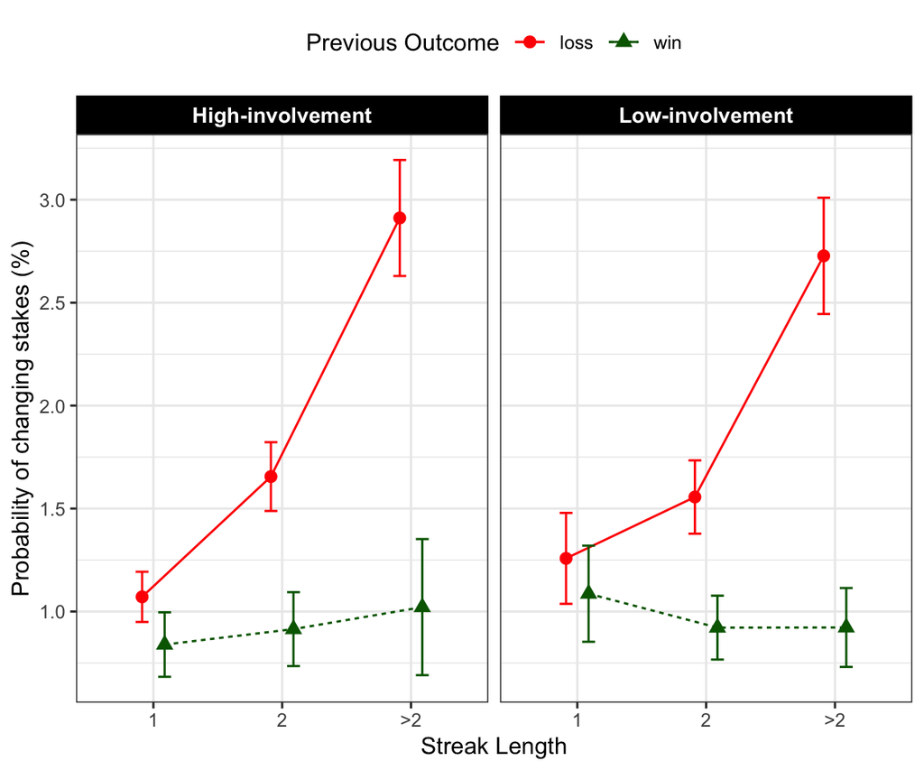

```r
stake_change_prob_plot <- stake_change_prob_summary %>%
  group_by(group_levels)%>%
  ggplot(aes(prev_streak_len, stake_change_prop,color = prev_outcome, shape = prev_outcome)) +
  geom_point(position = position_dodge(width = dodge_width), size = shape_size) +
  geom_line(aes(group = prev_outcome, linetype = prev_outcome),
            position = position_dodge(width = dodge_width)) +
  geom_errorbar(aes(ymin = stake_change_prop-ci, ymax = stake_change_prop+ci), width = 0.2,
                position = position_dodge(width = dodge_width)) +
  # use colorblind-friendly color
  scale_color_manual(values=color_values_streaks) +
  scale_x_discrete(labels=c("1" = "1", "2" = "2", ">2" = ">2")) +
  labs(x = "Streak Length",
       y = "Probability of changing stakes (%)")+
  theme(legend.position = "top", legend.direction = "horizontal") +
  facet_wrap(~group_levels) +
  labs(color = "Previous Outcome",
       shape = "Previous Outcome",
       linetype = "Previous Outcome")+
    theme(
      strip.text.x = element_text(
        size = 10, color = "white", face = "bold"
        ),
      strip.text.y = element_text(
        size = 10, color = "black", face = "bold.italic"
        )
      ) +
  theme(
   strip.background = element_rect(
     color="black", fill="black", size=1, linetype="solid"
     )
   )


stake_change_prob_plot
```

```r
ggsave("figure/stake_change_prob_plot.png", stake_change_prob_plot, width = 6, height = 3)
```

```r
#add plot titles
#stake_change_plot <- stake_change_plot + ggtitle("Change in Stake")
#stake_change_prob_plot <- stake_change_prob_plot + ggtitle("Likelihood of Changing Stake")

#combined_plots <- (stake_change_plot_main) / (stake_change_prob_plot_main) +
#  plot_layout(guides = "collect") & theme(legend.position = "bottom")

#stake_all_plot <- cowplot::plot_grid(stake_change_plot, stake_change_prob_plot, nrow=2,
                               #rel_heights = c(1/2,1/2))
#stake_all_plot
#ggsave("figure/stake_all_plot.png", stake_all_plot, width = 10, height = 5)

#par(mfrow=2:1)
#stake_change_plot
#stake_change_prob_plot

#par(mfrow = c(1, 2))
#stake_change_plot
#stake_change_prob_plot
```

## Pairwise comparison: Stake change probability

Next we will conduct 4 bonferroni-correct post-hoc t-test pairwise comparisons. In the paired t-tests we will compare the overall mean probability of changing stake sizes across each prior outcome and streak lengths:

Paired t-test: * High-loss vs. High-win_ streak_len_1 * High-loss vs. High-win_ streak_len_2 * High-loss vs. High-win_ streak_len_grt_2 * Low-loss vs. Low-win_ streak_len_1 * Low-loss vs. Low-win_ streak_len_2 * Low-loss vs. Low-win_ streak_len_grt_2

Independent t-test: In the independent group comparison we will compare the two groups - high- and low-involvement groups across each prior outcome and streak lengths and the difference of differences as well.

- High-loss vs. Low-loss_ streak_len_1
- High-loss vs. Low-loss_ streak_len_2
- High-loss vs. Low-loss_ streak_len_grt_2
- High-win vs. Low-win_ streak_len_1
- High-win vs. Low-win_ streak_len_2
- High-win vs. Low-win_ streak_len_grt_2
- (High-Loss - High-Win) vs. (Low-Loss - Low-Win)_streak_len_1
- (High-Loss - High-Win) vs. (Low-Loss - Low-Win)_streak_len_2
- (High-Loss - High-Win) vs. (Low-Loss - Low-Win)_streak_len_grt_2

```r
# Format the table

stake_change_prob_wide <- stake_change_df%>%
  pivot_wider(id_cols = c(group_levels, player_id, prev_streak_len),
              names_from = prev_outcome,
              values_from = stake_change_prop)%>%
  mutate(diff_mean = loss - win)


## PAIRED T-TEST

# within-group comparison

comp_within_prob <- stake_change_prob_wide %>%
  group_by(group_levels, prev_streak_len)%>%
  group_modify(~TES(.x$loss, .x$win, paired = TRUE))%>%
  mutate(d = dz, g = gav)%>%
  ungroup() %>%
  select(-group_levels, -dz, -gav, -dav)


comp_within_prob_table <- comp_within_prob%>%
  mutate(
    Comparison_group = c("High-Loss vs. High-Win",
                   "High-Loss vs. High-Win",
                   "High-Loss vs. High-Win",
                   "Low-Loss vs. Low-Win",
                   "Low-Loss vs. Low-Win",
                   "Low-Loss vs. Low-Win"),
    Comparison_streak_len = c("1", "2", ">2",
                              "1", "2", ">2")
    ,pt = p.adjust(pt, method = "holm"))

comp_within_prob_table <- comp_within_prob_table%>%
  mutate(
    across(mean_x:upperCI, ~round(.x, digits = 3)),
    across(c(d,g), ~round(.x, digits = 3)),
    t = round(t, digits = 1),
    df = round(df, digits = 1),
    p = ifelse(pt <.001, "<.001", sprintf("%.3f", round(pt, digits = 3))),
    logBF = round(logBF, digits = 2)
  )%>%
  select(Comparison_group, Comparison_streak_len, mean_x:t, p, logBF, g)




## INDEPENDENT T-TEST

#between-group comparison

#Streak_len = 1
comp_between1_strk_1_prob <- TES(filter(stake_change_prob_wide, group_levels == "High-involvement", prev_streak_len == "1")$loss,
                     filter(stake_change_prob_wide, group_levels == "Low-involvement", prev_streak_len == "1")$loss, paired = FALSE)

comp_between2_strk_1_prob <- TES(filter(stake_change_prob_wide, group_levels == "High-involvement", prev_streak_len == "1")$win,
                     filter(stake_change_prob_wide, group_levels == "Low-involvement", prev_streak_len == "1")$win, paired = FALSE)

comp_between3_strk_1_prob <- TES(filter(stake_change_prob_wide, group_levels == "High-involvement", prev_streak_len == "1")$diff_mean,
                     filter(stake_change_prob_wide, group_levels == "Low-involvement", prev_streak_len == "1")$diff_mean, paired = FALSE)

#Streak_len = 2
comp_between1_strk_2_prob <- TES(filter(stake_change_prob_wide, group_levels == "High-involvement", prev_streak_len == "2")$loss,
                     filter(stake_change_prob_wide, group_levels == "Low-involvement", prev_streak_len == "2")$loss, paired = FALSE)

comp_between2_strk_2_prob <- TES(filter(stake_change_prob_wide, group_levels == "High-involvement", prev_streak_len == "2")$win,
                     filter(stake_change_prob_wide, group_levels == "Low-involvement", prev_streak_len == "2")$win, paired = FALSE)

comp_between3_strk_2_prob <- TES(filter(stake_change_prob_wide, group_levels == "High-involvement", prev_streak_len == "2")$diff_mean,
                     filter(stake_change_prob_wide, group_levels == "Low-involvement", prev_streak_len == "2")$diff_mean, paired = FALSE)

#Streak_len = >2
comp_between1_strk_grt_2_prob <- TES(filter(stake_change_prob_wide, group_levels == "High-involvement", prev_streak_len == ">2")$loss,
                     filter(stake_change_prob_wide, group_levels == "Low-involvement", prev_streak_len == ">2")$loss, paired = FALSE)

comp_between2_strk_grt_2_prob <- TES(filter(stake_change_prob_wide, group_levels == "High-involvement", prev_streak_len == ">2")$win,
                     filter(stake_change_prob_wide, group_levels == "Low-involvement", prev_streak_len == ">2")$win, paired = FALSE)

comp_between3_strk_grt_2_prob <- TES(filter(stake_change_prob_wide, group_levels == "High-involvement", prev_streak_len == ">2")$diff_mean,
                     filter(stake_change_prob_wide, group_levels == "Low-involvement", prev_streak_len == ">2")$diff_mean, paired = FALSE)



# Combine all df's from the between-group comparison

comp_between_prob <- bind_rows(comp_between1_strk_1_prob, #high-loss vs. low-loss _ strk_len1
                      comp_between1_strk_2_prob, #high-loss vs. low-loss _ strk_len
                      comp_between1_strk_grt_2_prob, #high-loss vs. low-loss _ strk_len_grt_2
                      comp_between2_strk_1_prob, #high-win vs. low-win _ strk_len1
                      comp_between2_strk_2_prob, #high-win vs. low-win _ strk_len2
                      comp_between2_strk_grt_2_prob, #high-win vs. low-win _ strk_len_grt_2
                      comp_between3_strk_1_prob, #(High-Loss - High-Win) vs. (Low-Loss - Low-Win)_streak_len1
                      comp_between3_strk_2_prob, #(High-Loss - High-Win) vs. (Low-Loss - Low-Win)_streak_len2
                      comp_between3_strk_grt_2_prob) #(High-Loss - High-Win) vs. (Low-Loss - Low-Win)_streak_len_grt_2


comp_between_prob_table <- comp_between_prob %>%
  mutate(
    Comparison_group = c("High-Loss vs. Low-Loss",
                         "High-Loss vs. Low-Loss",
                         "High-Loss vs. Low-Loss",
                         "High-Win vs. Low-Win",
                         "High-Win vs. Low-Win",
                         "High-Win vs. Low-Win",
                         "(High-Loss - High-Win) vs. (Low-Loss - Low-Win)",
                         "(High-Loss - High-Win) vs. (Low-Loss - Low-Win)",
                         "(High-Loss - High-Win) vs. (Low-Loss - Low-Win)"),
    Comparison_streak_len = c("1", "2", ">2",
                              "1", "2", ">2",
                              "1", "2", ">2")
    ,pt = p.adjust(pt, method = "holm"))


comp_between_prob_table <- comp_between_prob_table%>%
  mutate(
    across(mean_x:upperCI, ~round(.x, digits = 3)),
    across(c(d,g), ~round(.x, digits = 3)),
    t = round(t, digits = 1),
    df = round(df, digits = 1),
    p = ifelse(pt <.001, "<.001", sprintf("%.3f", round(pt, digits = 3))),
    logBF = round(logBF, digits = 2)
  )%>%
  select(Comparison_group, Comparison_streak_len, mean_x:t, p, logBF, g)


#create the final df with all the within and between comparisons
final_comp_between_within_prob <- rbind(comp_within_prob_table, comp_between_prob_table)
# save the df as a csv
write_csv(final_comp_between_within_prob, file = here("data/processed_data/EDA/Within_session/final_comp_between_within_prob.csv"))
```

# Stake level change overall (additional analyses)

```r
#free R's memory

#rm(list=setdiff(ls(), "stake_change_df"))
```

## Mixed ANOVA Model: Stake level change

```r
stake_change_level_anova <- aov_ez(id = "player_id",
                        dv = "stake_change_level_overall",
                        between = "group_levels",
                        within = c("prev_streak_len","prev_outcome"),
                        data = stake_change_df,
                        na.rm = TRUE)
stake_change_level_anova_table <- nice(stake_change_level_anova)

# format the anova table
stake_change_level_anova_table <- stake_change_level_anova_table%>%
  mutate(
    Parameter = "Change in stake level (euro)",
    Effect = c("Involvement Level", "Streak Length","Interaction: Involvement level * Streak length",
               "Prior Outcome", "Interaction: Involvement level * Prior Outcome",
               "Interaction: Streak length * Prior Outcome" ,
               "Interaction: Streak length * Streak length * Prior Outcome"),
    # remove asterisks from the F values
    `F` = str_remove_all(`F`, "[*]"),
    # remove white space
    `F` = str_trim(`F`),
    p = `p.value`
  ) %>%
  #select(Parameter, Effect, df, MSE, `F`, ges, p)
  select(Effect, df, MSE, `F`, ges, p)

stake_change_level_anova_table %>%
  kable() %>%
  kable_styling() %>%
  scroll_box(width = "100%", height = "400px")
```

| Effect | df | MSE | F | ges | p |
| --- | --- | --- | --- | --- | --- |
| Involvement Level | 1, 1004 | 0.00 | 0.46 | <.001 | .497 |
| Streak Length | 1.73, 1735.32 | 0.00 | 13.11 | .001 | <.001 |
| Interaction: Involvement level * Streak length | 1.73, 1735.32 | 0.00 | 0.74 | <.001 | .457 |
| Prior Outcome | 1, 1004 | 0.00 | 24.08 | .011 | <.001 |
| Interaction: Involvement level * Prior Outcome | 1, 1004 | 0.00 | 0.56 | <.001 | .453 |
| Interaction: Streak length * Prior Outcome | 1.28, 1281.20 | 0.00 | 8.60 | .003 | .002 |
| Interaction: Streak length * Streak length * Prior Outcome | 1.28, 1281.20 | 0.00 | 0.95 | <.001 | .352 |

## Plots - Stake level change

```r
#check the players that don't have a stake level change and remove them
rm_player <- stake_change_df %>%
  filter(is.na(stake_change_level_overall))

stake_change_df <- stake_change_df %>%
  filter(!(player_id %in% rm_player$player_id))

stake_change_level_summary <- stake_change_df %>%
  # use euro cents instead of euros as the unit
  group_by(group_levels) %>%
  group_modify(~Rmisc::summarySEwithin(.x,
                                       measurevar = "stake_change_level_overall",
                                       idvar = "player_id",
                                       withinvars = c("prev_outcome", "prev_streak_len")))%>%
  mutate(
    prev_streak_len = factor(prev_streak_len, levels = c("1", "2", ">2"),
                   labels = c("1", "2", ">2"))
  )%>%
  ungroup()
```

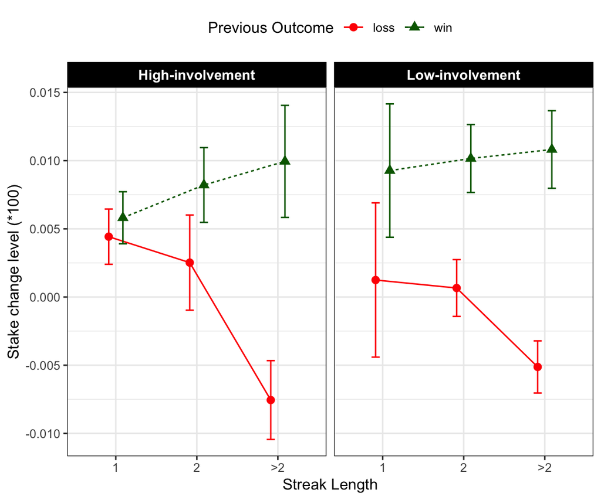

```r
stake_change_level_plot <- stake_change_level_summary %>%
  group_by(group_levels)%>%
  ggplot(aes(prev_streak_len, stake_change_level_overall,color = prev_outcome, shape = prev_outcome)) +
  geom_point(position = position_dodge(width = dodge_width), size = shape_size) +
  geom_line(aes(group = prev_outcome, linetype = prev_outcome),
            position = position_dodge(width = dodge_width)) +
  geom_errorbar(aes(ymin = stake_change_level_overall-ci,
                    ymax = stake_change_level_overall+ci),
                width = 0.2,
                position = position_dodge(width = dodge_width)) +
  # use colorblind-friendly color
  scale_color_manual(values=color_values_streaks) +
  scale_x_discrete(labels=c("1" = "1", "2" = "2", ">2" = ">2")) +
  labs(x = "Streak Length",
       y = "Stake change level (*100)")+
  theme(legend.position = "top", legend.direction = "horizontal") +
  facet_wrap(~group_levels) +
  labs(color = "Previous Outcome",
       shape = "Previous Outcome",
       linetype = "Previous Outcome")+
    theme(
      strip.text.x = element_text(
        size = 10, color = "white", face = "bold"
        ),
      strip.text.y = element_text(
        size = 10, color = "black", face = "bold.italic"
        )
      ) +
  theme(
   strip.background = element_rect(
     color="black", fill="black", size=1, linetype="solid"
     )
   )


stake_change_level_plot
```

```r
ggsave("figure/stake_change_level_plot.png", stake_change_level_plot, width = 6, height = 3)
```

## Pairwise comparison

Next we will conduct 4 bonferroni-correct post-hoc t-test pairwise comparisons. In the first paired t-tests we will compare the overall mean stake size change across each prior outcome and streak lengths:

Paired t-test: * High-loss vs. High-win_ streak_len_1 * High-loss vs. High-win_ streak_len_2 * High-loss vs. High-win_ streak_len_grt_2 * Low-loss vs. Low-win_ streak_len_1 * Low-loss vs. Low-win_ streak_len_2 * Low-loss vs. Low-win_ streak_len_grt_2

Independent t-test: In the independent group comparison we will compare the two groups - high- and low-involvement groups across each prior outcome and streak lengths and the difference of differences as well.

- High-loss vs. Low-loss_ streak_len_1
- High-loss vs. Low-loss_ streak_len_2
- High-loss vs. Low-loss_ streak_len_grt_2
- High-win vs. Low-win_ streak_len_1
- High-win vs. Low-win_ streak_len_2
- High-win vs. Low-win_ streak_len_grt_2
- (High-Loss - High-Win) vs. (Low-Loss - Low-Win)_streak_len_1
- (High-Loss - High-Win) vs. (Low-Loss - Low-Win)_streak_len_2
- (High-Loss - High-Win) vs. (Low-Loss - Low-Win)_streak_len_grt_2

```r
# Format the table

stake_change_level_overall_wide <- stake_change_df%>%
  pivot_wider(id_cols = c(group_levels, player_id, prev_streak_len),
              names_from = prev_outcome,
              values_from = stake_change_level_overall)%>%
  mutate(diff_mean = loss - win)


## PAIRED T-TEST

# within-group comparison

comp_within <- stake_change_level_overall_wide %>%
  group_by(group_levels, prev_streak_len)%>%
  group_modify(~TES(.x$loss, .x$win, paired = TRUE))%>%
  mutate(d = dz, g = gav)%>%
  ungroup() %>%
  select(-group_levels, -dz, -gav, -dav)


comp_within_table <- comp_within%>%
  mutate(
    Comparison_group = c("High-Loss vs. High-Win",
                   "High-Loss vs. High-Win",
                   "High-Loss vs. High-Win",
                   "Low-Loss vs. Low-Win",
                   "Low-Loss vs. Low-Win",
                   "Low-Loss vs. Low-Win"),
    Comparison_streak_len = c("1", "2", ">2",
                              "1", "2", ">2")
    ,pt = p.adjust(pt, method = "holm"))

comp_within_table <- comp_within_table%>%
  mutate(
    across(mean_x:upperCI, ~round(.x, digits = 3)),
    across(c(d,g), ~round(.x, digits = 3)),
    t = round(t, digits = 1),
    df = round(df, digits = 1),
    p = ifelse(pt <.001, "<.001", sprintf("%.3f", round(pt, digits = 3))),
    logBF = round(logBF, digits = 2)
  )%>%
  select(Comparison_group, Comparison_streak_len, mean_x:t, p, logBF, g)


## INDEPENDENT T-TEST

#between-group comparison

#Streak_len = 1

#losses
comp_between1_strk_1 <- TES(filter(stake_change_level_overall_wide, group_levels == "High-involvement", prev_streak_len == "1")$loss,
                     filter(stake_change_level_overall_wide, group_levels == "Low-involvement", prev_streak_len == "1")$loss, paired = FALSE)

#wins
comp_between2_strk_1 <- TES(filter(stake_change_level_overall_wide, group_levels == "High-involvement", prev_streak_len == "1")$win,
                     filter(stake_change_level_overall_wide, group_levels == "Low-involvement", prev_streak_len == "1")$win, paired = FALSE)

#difference of differences
comp_between3_strk_1 <- TES(filter(stake_change_level_overall_wide, group_levels == "High-involvement", prev_streak_len == "1")$diff_mean,
                     filter(stake_change_level_overall_wide, group_levels == "Low-involvement", prev_streak_len == "1")$diff_mean, paired = FALSE)

#Streak_len = 2

#losses
comp_between1_strk_2 <- TES(filter(stake_change_level_overall_wide, group_levels == "High-involvement", prev_streak_len == "2")$loss,
                     filter(stake_change_level_overall_wide, group_levels == "Low-involvement", prev_streak_len == "2")$loss, paired = FALSE)

#wins
comp_between2_strk_2 <- TES(filter(stake_change_level_overall_wide, group_levels == "High-involvement", prev_streak_len == "2")$win,
                     filter(stake_change_level_overall_wide, group_levels == "Low-involvement", prev_streak_len == "2")$win, paired = FALSE)

#difference of differences
comp_between3_strk_2 <- TES(filter(stake_change_level_overall_wide, group_levels == "High-involvement", prev_streak_len == "2")$diff_mean,
                     filter(stake_change_level_overall_wide, group_levels == "Low-involvement", prev_streak_len == "2")$diff_mean, paired = FALSE)

#Streak_len = >2

#losses
comp_between1_strk_grt_2 <- TES(filter(stake_change_level_overall_wide, group_levels == "High-involvement", prev_streak_len == ">2")$loss,
                     filter(stake_change_level_overall_wide, group_levels == "Low-involvement", prev_streak_len == ">2")$loss, paired = FALSE)

#wins
comp_between2_strk_grt_2 <- TES(filter(stake_change_level_overall_wide, group_levels == "High-involvement", prev_streak_len == ">2")$win,
                     filter(stake_change_level_overall_wide, group_levels == "Low-involvement", prev_streak_len == ">2")$win, paired = FALSE)

#difference of differences
comp_between3_strk_grt_2 <- TES(filter(stake_change_level_overall_wide, group_levels == "High-involvement", prev_streak_len == ">2")$diff_mean,
                     filter(stake_change_level_overall_wide, group_levels == "Low-involvement", prev_streak_len == ">2")$diff_mean, paired = FALSE)


# Combine all df's from the between-group comparison

comp_between <- bind_rows(comp_between1_strk_1, #high-loss vs. low-loss _ strk_len1
                      comp_between1_strk_2, #high-loss vs. low-loss _ strk_len
                      comp_between1_strk_grt_2, #high-loss vs. low-loss _ strk_len_grt_2
                      comp_between2_strk_1, #high-win vs. low-win _ strk_len1
                      comp_between2_strk_2, #high-win vs. low-win _ strk_len2
                      comp_between2_strk_grt_2, #high-win vs. low-win _ strk_len_grt_2
                      comp_between3_strk_1, #(High-Loss - High-Win) vs. (Low-Loss - Low-Win)_streak_len1
                      comp_between3_strk_2, #(High-Loss - High-Win) vs. (Low-Loss - Low-Win)_streak_len2
                      comp_between3_strk_grt_2) #(High-Loss - High-Win) vs. (Low-Loss - Low-Win)_streak_len_grt_2

comp_between_table <- comp_between %>%
  mutate(
    Comparison_group = c("High-Loss vs. Low-Loss",
                         "High-Loss vs. Low-Loss",
                         "High-Loss vs. Low-Loss",
                         "High-Win vs. Low-Win",
                         "High-Win vs. Low-Win",
                         "High-Win vs. Low-Win",
                         "(High-Loss - High-Win) vs. (Low-Loss - Low-Win)",
                         "(High-Loss - High-Win) vs. (Low-Loss - Low-Win)",
                         "(High-Loss - High-Win) vs. (Low-Loss - Low-Win)"),
    Comparison_streak_len = c("1", "2", ">2",
                              "1", "2", ">2",
                              "1", "2", ">2")
    ,pt = p.adjust(pt, method = "holm"))


comp_between_table <- comp_between_table%>%
  mutate(
    across(mean_x:upperCI, ~round(.x, digits = 3)),
    across(c(d,g), ~round(.x, digits = 3)),
    t = round(t, digits = 1),
    df = round(df, digits = 1),
    p = ifelse(pt <.001, "<.001", sprintf("%.3f", round(pt, digits = 2))),
    logBF = round(logBF, digits = 2)
  )%>%
  select(Comparison_group, Comparison_streak_len, mean_x:t, p, logBF, g)


#create the final df with all the within and between comparisons
final_comp_between_within <- rbind(comp_within_table, comp_between_table)

final_comp_between_within %>%
  kable() %>%
  kable_styling() %>%
  scroll_box(width = "100%", height = "400px")
```

| Comparison_group | Comparison_streak_len | mean_x | sd_x | mean_y | sd_y | diff | lowerCI | upperCI | df | t | p | logBF | g |
| --- | --- | --- | --- | --- | --- | --- | --- | --- | --- | --- | --- | --- | --- |
| High-Loss vs. High-Win | 1 | 0.004 | 0.016 | 0.006 | 0.021 | -0.001 | -0.004 | 0.001 | 291.0 | -1.0 | 0.331 | -2.26 | 0.075 |
| High-Loss vs. High-Win | 2 | 0.003 | 0.033 | 0.008 | 0.025 | -0.006 | -0.011 | -0.001 | 291.0 | -2.2 | 0.091 | -0.39 | 0.194 |
| High-Loss vs. High-Win | >2 | -0.008 | 0.021 | 0.010 | 0.037 | -0.018 | -0.023 | -0.012 | 291.0 | -6.3 | <.001 | 15.77 | 0.606 |
| Low-Loss vs. Low-Win | 1 | 0.001 | 0.065 | 0.009 | 0.066 | -0.008 | -0.018 | 0.001 | 713.0 | -1.7 | 0.194 | -1.79 | 0.122 |
| Low-Loss vs. Low-Win | 2 | 0.001 | 0.022 | 0.010 | 0.040 | -0.009 | -0.013 | -0.006 | 713.0 | -4.8 | <.001 | 7.91 | 0.306 |
| Low-Loss vs. Low-Win | >2 | -0.005 | 0.018 | 0.011 | 0.045 | -0.016 | -0.020 | -0.012 | 713.0 | -8.0 | <.001 | 27.37 | 0.501 |
| High-Loss vs. Low-Loss | 1 | 0.004 | 0.016 | 0.001 | 0.065 | 0.003 | -0.002 | 0.008 | 882.0 | 1.2 | 1.000 | -2.23 | 0.084 |
| High-Loss vs. Low-Loss | 2 | 0.003 | 0.033 | 0.001 | 0.022 | 0.002 | -0.002 | 0.006 | 397.8 | 0.9 | 1.000 | -2.02 | 0.061 |
| High-Loss vs. Low-Loss | >2 | -0.008 | 0.021 | -0.005 | 0.018 | -0.002 | -0.005 | 0.000 | 491.1 | -1.7 | 0.740 | -0.92 | 0.121 |
| High-Win vs. Low-Win | 1 | 0.006 | 0.021 | 0.009 | 0.066 | -0.003 | -0.009 | 0.002 | 970.9 | -1.3 | 1.000 | -2.18 | 0.087 |
| High-Win vs. Low-Win | 2 | 0.008 | 0.025 | 0.010 | 0.040 | -0.002 | -0.006 | 0.002 | 837.8 | -0.9 | 1.000 | -2.27 | 0.064 |
| High-Win vs. Low-Win | >2 | 0.010 | 0.037 | 0.011 | 0.045 | -0.001 | -0.006 | 0.005 | 654.3 | -0.3 | 1.000 | -2.51 | 0.022 |
| (High-Loss - High-Win) vs. (Low-Loss - Low-Win) | 1 | -0.001 | 0.024 | -0.008 | 0.129 | 0.007 | -0.003 | 0.017 | 827.3 | 1.3 | 1.000 | -2.18 | 0.092 |
| (High-Loss - High-Win) vs. (Low-Loss - Low-Win) | 2 | -0.006 | 0.045 | -0.009 | 0.053 | 0.004 | -0.003 | 0.010 | 641.3 | 1.2 | 1.000 | -1.99 | 0.080 |
| (High-Loss - High-Win) vs. (Low-Loss - Low-Win) | >2 | -0.018 | 0.047 | -0.016 | 0.053 | -0.002 | -0.008 | 0.005 | 603.5 | -0.5 | 1.000 | -2.46 | 0.032 |

# Speed of Play

```r
# load data
rt_df <- read_csv(here("data", "processed_data","EDA", "Within_session", "rt_df.csv"))
```

Players may chase losses by increasing the speed of playing following losses. In this script we will analyse if players increase their speed of play following losses and wins across varying streak lengths of - 1.) 1, 2.) 2 and 3.) >2 streak length. We will run a mixed anova model (2 x 2 x 3 design) in which the between-group factor is group levels (high- and low-involvement) and the within-group factors is a.) previous round outcome and b.) streak length. The dependent variable here is the overall mean z-transformed RT scores.

```r
# number of players in the stakes df
n_players <- rt_df %>%
  group_by(group_levels) %>%
  distinct(player_id) %>%
  count()

#info about number of rounds

n_round <- rt_df %>%
  group_by(group_levels) %>%
  summarise(total_rounds = sum(n_round),
            mean_rounds = mean(n_round),
            sd_rounds = sd(n_round),
            min_rounds = min(n_round),
            max_rounds = max(n_round))
```

## Mixed ANOVA Model: Speed of Play (zRT)

```r
rt_z_anova <- aov_ez(id = "player_id",
                        dv = "rt_z_mean",
                        between = "group_levels",
                        within = c("prev_streak_len","prev_outcome"),
                        data = rt_df,
                        na.rm = TRUE)
rt_z_anova_table <- nice(rt_z_anova)

# format the anova table
rt_z_anova_table <- rt_z_anova_table%>%
  mutate(
    Parameter = "RT (in z-scores)",
    Effect = c("Involvement level", "Streak Length","Interaction: Involvement level * Streak length",
               "Prior Outcome", "Interaction: Involvement level * Prior Outcome",
               "Interaction: Streak length * Prior Outcome" ,
               "Interaction: Involvement level * Streak length * Prior Outcome"),
    # remove asterisks from the F values
    `F` = str_remove_all(`F`, "[*]"),
    # remove white space
    `F` = str_trim(`F`),
    p = `p.value`
  ) %>%
  #select(Parameter, Effect, df, MSE, `F`, ges, p)
  select(Effect, df, MSE, `F`, ges, p)

rt_z_anova_table %>%
  kable() %>%
  kable_styling() %>%
  scroll_box(width = "100%", height = "400px")
```

| Effect | df | MSE | F | ges | p |
| --- | --- | --- | --- | --- | --- |
| Involvement level | 1, 1003 | 0.05 | 0.00 | <.001 | .983 |
| Streak Length | 1.40, 1401.69 | 0.04 | 2.73 + | <.001 | .084 |
| Interaction: Involvement level * Streak length | 1.40, 1401.69 | 0.04 | 2.21 | <.001 | .127 |
| Prior Outcome | 1, 1003 | 0.11 | 583.08 | .198 | <.001 |
| Interaction: Involvement level * Prior Outcome | 1, 1003 | 0.11 | 0.86 | <.001 | .355 |
| Interaction: Streak length * Prior Outcome | 1.41, 1418.79 | 0.04 | 0.61 | <.001 | .490 |
| Interaction: Involvement level * Streak length * Prior Outcome | 1.41, 1418.79 | 0.04 | 0.19 | <.001 | .748 |

```r
#write_csv(rt_z_anova_table, file = here("data/processed_data/EDA/Within_session/rt_z_anova_table.csv"))
```

## Plots: Speed of Play (zRT)

```r
rt_z_summary <- rt_df %>%
  group_by(group_levels) %>%
  group_modify(~Rmisc::summarySEwithin(.x,
                                       measurevar = "rt_z_mean",
                                       idvar = "player_id",
                                       withinvars = c("prev_outcome", "prev_streak_len")))%>%
  mutate(
    prev_streak_len = factor(prev_streak_len, levels = c("1", "2", ">2"),
                   labels = c("1", "2", ">2"))
  )%>%
  ungroup()
```

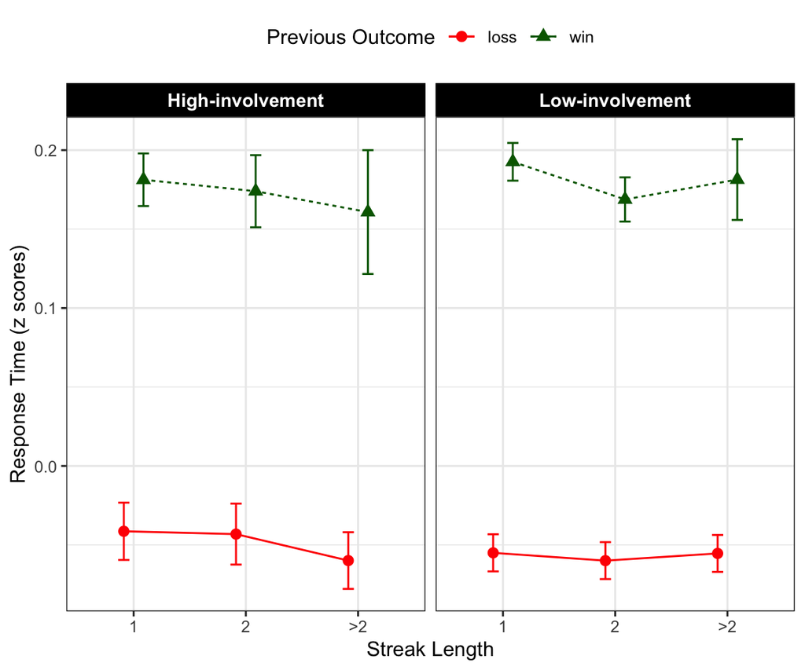

```r
rt_z_plot <- rt_z_summary %>%
  group_by(group_levels)%>%
  ggplot(aes( prev_streak_len, rt_z_mean,
              color = prev_outcome, shape = prev_outcome)) +
  geom_point(position = position_dodge(width = dodge_width), size = shape_size) +
  geom_line(aes(group = prev_outcome, linetype = prev_outcome),
            position = position_dodge(width = dodge_width)) +
  geom_errorbar(aes(ymin = rt_z_mean-ci, ymax = rt_z_mean+ci), width = 0.2,
                position = position_dodge(width = dodge_width)) +
  # use colorblind-friendly color
  scale_color_manual(values=color_values_streaks) +
  scale_x_discrete(labels=c("loss" = "Loss", "win" = "Win"))+
  labs(x = "Streak Length",
       y = "Response Time (z scores)")+
  theme(legend.position = "top", legend.direction = "horizontal") +
  facet_wrap(~group_levels) +
  labs(color = "Previous Outcome",
       shape = "Previous Outcome",
       linetype = "Previous Outcome")+
    theme(
      strip.text.x = element_text(
        size = 10, color = "white", face = "bold"
        ),
      strip.text.y = element_text(
        size = 10, color = "black", face = "bold.italic"
        )
      ) +
  theme(
   strip.background = element_rect(
     color="black", fill="black", size=1, linetype="solid"
     )
   )


rt_z_plot
```

```r
ggsave("figure/rt_z_plot.png", rt_z_plot, width = 6, height = 3)
```

## Pairwise comparison: Speed of Play (zRT)

Next we will conduct 4 bonferroni-correct post-hoc t-test pairwise comparisons. In the paired t-tests we will compare the overall mean z-transformed RT’s across each prior outcome and streak lengths:

Paired t-test: * High-loss vs. High-win_ streak_len_1 * High-loss vs. High-win_ streak_len_2 * High-loss vs. High-win_ streak_len_grt_2 * Low-loss vs. Low-win_ streak_len_1 * Low-loss vs. Low-win_ streak_len_2 * Low-loss vs. Low-win_ streak_len_grt_2

Independent t-test: In the independent group comparison we will compare the two groups - high- and low-involvement groups across each prior outcome and streak lengths and the difference of differences as well.

- High-loss vs. Low-loss_ streak_len_1
- High-loss vs. Low-loss_ streak_len_2
- High-loss vs. Low-loss_ streak_len_grt_2
- High-win vs. Low-win_ streak_len_1
- High-win vs. Low-win_ streak_len_2
- High-win vs. Low-win_ streak_len_grt_2
- (High-Loss - High-Win) vs. (Low-Loss - Low-Win)_streak_len_1
- (High-Loss - High-Win) vs. (Low-Loss - Low-Win)_streak_len_2
- (High-Loss - High-Win) vs. (Low-Loss - Low-Win)_streak_len_grt_2

```r
# Format the table

rt_z_wide <- rt_df%>%
  pivot_wider(id_cols = c(group_levels, player_id, prev_streak_len),
              names_from = prev_outcome,
              values_from = rt_z_mean)%>%
  mutate(diff_mean = loss - win)


## PAIRED T-TEST

# within-group comparison

comp_within <- rt_z_wide %>%
  group_by(group_levels, prev_streak_len)%>%
  group_modify(~TES(.x$loss, .x$win, paired = TRUE))%>%
  mutate(d = dz, g = gav)%>%
  ungroup() %>%
  select(-group_levels, -dz, -gav, -dav)


comp_within_table <- comp_within%>%
  mutate(
    Comparison_group = c("High-Loss vs. High-Win",
                   "High-Loss vs. High-Win",
                   "High-Loss vs. High-Win",
                   "Low-Loss vs. Low-Win",
                   "Low-Loss vs. Low-Win",
                   "Low-Loss vs. Low-Win"),
    Comparison_streak_len = c("1", "2", ">2",
                              "1", "2", ">2")
    ,pt = p.adjust(pt, method = "holm"))

comp_within_table <- comp_within_table%>%
  mutate(
    across(mean_x:upperCI, ~round(.x, digits = 3)),
    across(c(d,g), ~round(.x, digits = 3)),
    t = round(t, digits = 1),
    df = round(df, digits = 1),
    p = ifelse(pt <.001, "<.001", sprintf("%.3f", round(pt, digits = 3))),
    logBF = round(logBF, digits = 2)
  )%>%
  select(Comparison_group, Comparison_streak_len, mean_x:t, p, logBF, g)




## INDEPENDENT T-TEST

#between-group comparison

#Streak_len = 1
comp_between1_strk_1 <- TES(filter(rt_z_wide, group_levels == "High-involvement", prev_streak_len == "1")$loss,
                     filter(rt_z_wide, group_levels == "Low-involvement", prev_streak_len == "1")$loss, paired = FALSE)

comp_between2_strk_1 <- TES(filter(rt_z_wide, group_levels == "High-involvement", prev_streak_len == "1")$win,
                     filter(rt_z_wide, group_levels == "Low-involvement", prev_streak_len == "1")$win, paired = FALSE)

comp_between3_strk_1 <- TES(filter(rt_z_wide, group_levels == "High-involvement", prev_streak_len == "1")$diff_mean,
                     filter(rt_z_wide, group_levels == "Low-involvement", prev_streak_len == "1")$diff_mean, paired = FALSE)

#Streak_len = 2
comp_between1_strk_2 <- TES(filter(rt_z_wide, group_levels == "High-involvement", prev_streak_len == "2")$loss,
                     filter(rt_z_wide, group_levels == "Low-involvement", prev_streak_len == "2")$loss, paired = FALSE)

comp_between2_strk_2 <- TES(filter(rt_z_wide, group_levels == "High-involvement", prev_streak_len == "2")$win,
                     filter(rt_z_wide, group_levels == "Low-involvement", prev_streak_len == "2")$win, paired = FALSE)

comp_between3_strk_2 <- TES(filter(rt_z_wide, group_levels == "High-involvement", prev_streak_len == "2")$diff_mean,
                     filter(rt_z_wide, group_levels == "Low-involvement", prev_streak_len == "2")$diff_mean, paired = FALSE)

#Streak_len = >2
comp_between1_strk_grt_2 <- TES(filter(rt_z_wide, group_levels == "High-involvement", prev_streak_len == ">2")$loss,
                     filter(rt_z_wide, group_levels == "Low-involvement", prev_streak_len == ">2")$loss, paired = FALSE)

comp_between2_strk_grt_2 <- TES(filter(rt_z_wide, group_levels == "High-involvement", prev_streak_len == ">2")$win,
                     filter(rt_z_wide, group_levels == "Low-involvement", prev_streak_len == ">2")$win, paired = FALSE)

comp_between3_strk_grt_2 <- TES(filter(rt_z_wide, group_levels == "High-involvement", prev_streak_len == ">2")$diff_mean,
                     filter(rt_z_wide, group_levels == "Low-involvement", prev_streak_len == ">2")$diff_mean, paired = FALSE)




# Combine all df's from the between-group comparison

comp_between <- bind_rows(comp_between1_strk_1, #high-loss vs. low-loss _ strk_len1
                      comp_between1_strk_2, #high-loss vs. low-loss _ strk_len2
                      comp_between1_strk_grt_2, #high-loss vs. low-loss _ strk_len_grt_2
                      comp_between2_strk_1, #high-win vs. low-win _ strk_len1
                      comp_between2_strk_2, #high-win vs. low-win _ strk_len2
                      comp_between2_strk_grt_2, #high-win vs. low-win _ strk_len_grt_2
                      comp_between3_strk_1, #(High-Loss - High-Win) vs. (Low-Loss - Low-Win)_streak_len1
                      comp_between3_strk_2, #(High-Loss - High-Win) vs. (Low-Loss - Low-Win)_streak_len2
                      comp_between3_strk_grt_2) #(High-Loss - High-Win) vs. (Low-Loss - Low-Win)_streak_len_grt_2



comp_between_table <- comp_between%>%
  mutate(
    Comparison_group = c("High-Loss vs. Low-Loss",
                         "High-Loss vs. Low-Loss",
                         "High-Loss vs. Low-Loss",
                         "High-Win vs. Low-Win",
                         "High-Win vs. Low-Win",
                         "High-Win vs. Low-Win",
                         "(High-Loss - High-Win) vs. (Low-Loss - Low-Win)",
                         "(High-Loss - High-Win) vs. (Low-Loss - Low-Win)",
                         "(High-Loss - High-Win) vs. (Low-Loss - Low-Win)"),
    Comparison_streak_len = c("1", "2", ">2",
                              "1", "2", ">2",
                              "1", "2", ">2")
    ,pt = p.adjust(pt, method = "holm"))


comp_between_table <- comp_between_table%>%
  mutate(
    across(mean_x:upperCI, ~round(.x, digits = 3)),
    across(c(d,g), ~round(.x, digits = 3)),
    t = round(t, digits = 1),
    df = round(df, digits = 1),
    p = ifelse(pt <.001, "<.001", sprintf("%.3f", round(pt, digits = 3))),
    logBF = round(logBF, digits = 2)
  )%>%
  select(Comparison_group, Comparison_streak_len, mean_x:t, p, logBF, g)


#create the final df with all the within and between comparisons
final_comp_between_within <- rbind(comp_within_table, comp_between_table)

write_csv(final_comp_between_within, file = here("data/processed_data/EDA/Within_session/final_comp_between_within.csv"))


final_comp_between_within %>%
  kable() %>%
  kable_styling() %>%
  scroll_box(width = "100%", height = "400px")
```

| Comparison_group | Comparison_streak_len | mean_x | sd_x | mean_y | sd_y | diff | lowerCI | upperCI | df | t | p | logBF | g |
| --- | --- | --- | --- | --- | --- | --- | --- | --- | --- | --- | --- | --- | --- |
| High-Loss vs. High-Win | 1 | -0.041 | 0.076 | 0.181 | 0.183 | -0.223 | -0.250 | -0.196 | 291.0 | -16.2 | <.001 | 90.43 | 1.716 |
| High-Loss vs. High-Win | 2 | -0.043 | 0.084 | 0.174 | 0.241 | -0.217 | -0.251 | -0.183 | 291.0 | -12.6 | <.001 | 59.76 | 1.335 |
| High-Loss vs. High-Win | >2 | -0.060 | 0.063 | 0.161 | 0.392 | -0.221 | -0.269 | -0.172 | 291.0 | -8.9 | <.001 | 32.14 | 0.971 |
| Low-Loss vs. Low-Win | 1 | -0.055 | 0.080 | 0.193 | 0.196 | -0.248 | -0.266 | -0.229 | 712.0 | -26.1 | <.001 | 235.22 | 1.788 |
| Low-Loss vs. Low-Win | 2 | -0.060 | 0.080 | 0.169 | 0.229 | -0.229 | -0.249 | -0.208 | 712.0 | -21.9 | <.001 | 179.63 | 1.481 |
| Low-Loss vs. Low-Win | >2 | -0.055 | 0.070 | 0.181 | 0.394 | -0.237 | -0.268 | -0.205 | 712.0 | -14.7 | <.001 | 91.11 | 1.019 |
| High-Loss vs. Low-Loss | 1 | -0.041 | 0.076 | -0.055 | 0.080 | 0.014 | 0.003 | 0.024 | 572.4 | 2.5 | 0.088 | 0.47 | 0.177 |
| High-Loss vs. Low-Loss | 2 | -0.043 | 0.084 | -0.060 | 0.080 | 0.017 | 0.006 | 0.028 | 517.9 | 2.9 | 0.032 | 1.83 | 0.204 |
| High-Loss vs. Low-Loss | >2 | -0.060 | 0.063 | -0.055 | 0.070 | -0.005 | -0.013 | 0.004 | 600.9 | -1.0 | 1.000 | -2.10 | 0.070 |
| High-Win vs. Low-Win | 1 | 0.181 | 0.183 | 0.193 | 0.196 | -0.011 | -0.037 | 0.014 | 576.3 | -0.9 | 1.000 | -2.20 | 0.061 |
| High-Win vs. Low-Win | 2 | 0.174 | 0.241 | 0.169 | 0.229 | 0.005 | -0.027 | 0.038 | 516.9 | 0.3 | 1.000 | -2.50 | 0.022 |
| High-Win vs. Low-Win | >2 | 0.161 | 0.392 | 0.181 | 0.394 | -0.021 | -0.074 | 0.033 | 544.6 | -0.8 | 1.000 | -2.28 | 0.052 |
| (High-Loss - High-Win) vs. (Low-Loss - Low-Win) | 1 | -0.223 | 0.234 | -0.248 | 0.253 | 0.025 | -0.008 | 0.058 | 581.7 | 1.5 | 0.939 | -1.52 | 0.104 |
| (High-Loss - High-Win) vs. (Low-Loss - Low-Win) | 2 | -0.217 | 0.296 | -0.229 | 0.279 | 0.012 | -0.028 | 0.051 | 514.0 | 0.6 | 1.000 | -2.39 | 0.040 |
| (High-Loss - High-Win) vs. (Low-Loss - Low-Win) | >2 | -0.221 | 0.423 | -0.237 | 0.429 | 0.016 | -0.042 | 0.074 | 548.8 | 0.5 | 1.000 | -2.41 | 0.038 |